# NBCUniversal - Box Office Forecasting

Chunzi Wang

March 20, 2018

```r
library(dplyr)
library(ggplot2)
library(tidyverse)
library(xlsx)
```

```r
movies <- read.xlsx2("C:/Users/Adimn/Desktop/NBCU-dataLaurel.xlsx",
                     sheetIndex=1,
                     colClasses = c("character","character","character","character","numeric","numeric","Date","character","character","numeric","character","character","Date","character","character","character","character","numeric","numeric"))
```

```r
dim(movies)
```

```
## [1] 8468   19
```

```r
str(movies)
```

```
## 'data.frame':    8468 obs. of  19 variables:
##  $ imdbid          : Factor w/ 8468 levels "tt0008133","tt0010323",..: 2 9 13 26 74 80 99 145 217 247 ...
##  $ title           : Factor w/ 8228 levels "'71","'night, Mother",..: 6361 2959 543 7683 3915 3682 2597 4721 947 5221 ...
##  $ plot            : Factor w/ 8163 levels "'4242' is the story of a young female immigrant, a story of a teenager's anguish who is trying to redefine her "| __truncated__,..: 4789 913 2375 4554 299 882 7198 2047 2750 8100 ...
##  $ rating          : Factor w/ 19 levels "","APPROVED",..: 18 7 7 5 5 5 9 18 3 5 ...
##  $ imdb_rating     : num  8.1 8 7.2 7.9 6.3 7.5 7.8 7.3 8 7.6 ...
##  $ metacritic      : num  NaN NaN NaN NaN NaN 95 67 72 95 82 ...
##  $ dvd_release     : Date, format: "1997-10-15" "2003-06-24" ...
##  $ production      : Factor w/ 1834 levels "","1-800-Love",..: 1362 1362 1362 396 1045 413 394 870 295 222 ...
##  $ actors          : Factor w/ 8131 levels "","'Bad' Chad Broussard, Jere' Folley Chaisson, 'Crazy' Tim Credeur, Derek Gauthier",..: 7905 2348 2203 5811 980 1524 962 503 6416 1365 ...
##  $ imdb_votes      : num  42583 21154 17801 5705 132 ...
##  $ poster          : Factor w/ 7967 levels "","http://ia.media-imdb.com/images/M/MV5BM2RlNTFhZmEtZDRjYS00ZGEyLThhMmUtYzk0MmQyYjMwNGM0XkEyXkFqcGdeQXVyNTIxMjA4M"| __truncated__,..: 4977 1739 5507 2576 4719 7237 3508 5400 5437 6806 ...
##  $ director        : Factor w/ 5877 levels "","A. Sarkunam",..: 4677 121 2380 1702 2995 4642 2171 340 1846 3864 ...
##  $ release_date    : Date, format: "1921-03-19" "1960-05-16" ...
##  $ runtime         : Factor w/ 194 levels "","1 min","10 min",..: 158 184 193 20 179 178 9 76 177 10 ...
##  $ genre           : Factor w/ 540 levels "","Action","Action, Adventure",..: 453 426 424 202 202 264 5 119 157 264 ...
##  $ awards          : Factor w/ 1144 levels "","1 nomination.",..: 2 777 26 14 493 213 904 2 1091 368 ...
##  $ keywords        : Factor w/ 6166 levels "","\\N","007|terrorist-cell|intelligence-agency|computer-cracker|official-james-bond-series|brawl|childhood-home|assassi"| __truncated__,..: 1832 3480 1718 2787 323 3921 4069 4225 954 5418 ...
##  $ Budget          : num  18000 88300 220000 6590 0 ...
##  $ Box.Office.Gross: num  0 0 46585 0 0 ...
```

```r
#head(movies)
```

Remove ‘plot’ and ‘poster’ column because they are not needed here.

```r
movies <- movies[,-c(3,11)]
summary(movies)
```

```
##        imdbid                          title            rating
##  tt0008133:   1   Untitled Fox/Marvel Film:   7   N/A      :3213
##  tt0010323:   1   Black Mass              :   3   R        :2237
##  tt0028212:   1   Cinderella              :   3   PG-13    :1344
##  tt0028358:   1   Sleepless               :   3   NOT RATED: 683
##  tt0042332:   1   The Night Before        :   3   PG       : 615
##  tt0046004:   1   The Switch              :   3   UNRATED  : 187
##  (Other)  :8462   (Other)                 :8446   (Other)  : 189
##   imdb_rating       metacritic      dvd_release
##  Min.   : 1.100   Min.   :  1.00   Min.   :1990-12-19
##  1st Qu.: 5.600   1st Qu.: 43.00   1st Qu.:2009-08-11
##  Median : 6.400   Median : 56.00   Median :2012-10-09
##  Mean   : 6.311   Mean   : 55.75   Mean   :2011-08-07
##  3rd Qu.: 7.100   3rd Qu.: 69.00   3rd Qu.:2015-03-17
##  Max.   :10.000   Max.   :100.00   Max.   :2017-12-04
##  NA's   :733      NA's   :3389     NA's   :3133
##                  production
##  N/A                  :1707
##  Universal Pictures   : 317
##  IFC Films            : 180
##  Warner Bros. Pictures: 161
##  20th Century Fox     : 159
##  Magnolia Pictures    : 146
##  (Other)              :5798
##                                                         actors
##  N/A                                                       : 312
##                                                            :   3
##  Bradley Cooper, Ed Helms, Zach Galifianakis, Justin Bartha:   3
##  Ian McKellen, Martin Freeman, Richard Armitage, Ken Stott :   3
##  Adam Sandler, Andy Samberg, Selena Gomez, Kevin James     :   2
##  Adam Sandler, Kevin James, Chris Rock, David Spade        :   2
##  (Other)                                                   :8143
##    imdb_votes                    director     release_date
##  Min.   :      5.0   N/A             :  75   Min.   :1917-06-17
##  1st Qu.:    453.5   Steven Spielberg:  21   1st Qu.:2010-07-09
##  Median :   2920.0   Tyler Perry     :  16   Median :2013-12-13
##  Mean   :  34865.7   Ron Howard      :  14   Mean   :2012-01-19
##  3rd Qu.:  20943.5   Spike Lee       :  13   3rd Qu.:2016-02-04
##  Max.   :1827477.0   Ram Gopal Varma :  12   Max.   :2025-12-19
##  NA's   :733         (Other)         :8317   NA's   :185
##     runtime                        genre                        awards
##  N/A    : 619   Drama                 : 774   N/A                  :3223
##  90 min : 400   Documentary           : 583   1 nomination.        : 671
##  95 min : 228   Comedy                : 426   2 nominations.       : 292
##  100 min: 225   Comedy, Drama         : 389   1 win.               : 291
##  92 min : 213   Comedy, Drama, Romance: 289   1 win & 1 nomination.: 213
##  93 min : 208   Drama, Romance        : 249   3 nominations.       : 166
##  (Other):6575   (Other)               :5758   (Other)              :3612
##                     keywords        Budget           Box.Office.Gross
##                         :2087   Min.   :-1.997e+03   Min.   :        0
##  f-rated                : 108   1st Qu.: 0.000e+00   1st Qu.:        0
##  character-name-in-title:  11   Median : 1.374e+05   Median :        0
##  cgi-animation          :  10   Mean   : 3.458e+07   Mean   : 14907664
##  independent-film       :   9   3rd Qu.: 1.050e+07   3rd Qu.:   621738
##  \\N                    :   8   Max.   : 3.500e+10   Max.   :936662225
##  (Other)                :6235   NA's   :3            NA's   :259
```

Look at the time span of the movies here. Ranging from Choplin’s film in 1917 till Avatar5 in 2025 that’re still in plan.

```r
# exclude keyword column here for tidiness
movies[,-15] %>%
  arrange(release_date) %>%
  top_n(10)
```

```
##       imdbid                                     title rating imdb_rating
## 1  tt0120338                                   Titanic  PG-13         7.7
## 2  tt0120915 Star Wars: Episode I - The Phantom Menace     PG         6.5
## 3  tt0468569                           The Dark Knight  PG-13         9.0
## 4  tt0499549                                    Avatar  PG-13         7.8
## 5  tt0848228                              The Avengers  PG-13         8.1
## 6  tt0369610                            Jurassic World  PG-13         7.0
## 7  tt2488496              Star Wars: The Force Awakens  PG-13         8.1
## 8  tt2277860                              Finding Dory     PG         7.4
## 9  tt3748528                                 Rogue One  PG-13         7.9
## 10 tt2771200                      Beauty and the Beast     PG         7.6
##    metacritic dvd_release                      production
## 1          74  2012-09-10              Paramount Pictures
## 2          51  2001-10-16                20th Century Fox
## 3          82  2008-12-09 Warner Bros. Pictures/Legendary
```

[output cut: 62 more lines]

```r
movies[,-15] %>%
  arrange(desc(release_date)) %>%
  top_n(10)
```

```
##       imdbid                                     title rating imdb_rating
## 1  tt2771200                      Beauty and the Beast     PG         7.6
## 2  tt3748528                                 Rogue One  PG-13         7.9
## 3  tt2277860                              Finding Dory     PG         7.4
## 4  tt2488496              Star Wars: The Force Awakens  PG-13         8.1
## 5  tt0369610                            Jurassic World  PG-13         7.0
## 6  tt0848228                              The Avengers  PG-13         8.1
## 7  tt0499549                                    Avatar  PG-13         7.8
## 8  tt0468569                           The Dark Knight  PG-13         9.0
## 9  tt0120915 Star Wars: Episode I - The Phantom Menace     PG         6.5
## 10 tt0120338                                   Titanic  PG-13         7.7
##    metacritic dvd_release                      production
## 1          65  2017-06-06            Walt Disney Pictures
## 2          65  2017-04-04            Walt Disney Pictures
## 3          77  2016-11-15      Walt Disney Pictures/PIXAR
```

[output cut: 62 more lines]

Put the movies that’re released after 2017 in a new set so we could predict the box office for them using historical box office value. (they have no budget and box office value in the dataframe now) To do that, first, we ned to seperate release date into new columns - year, month, and date.

```r
movies$release.year <- as.numeric(format(movies$release_date, format = "%Y"))
movies$release.month <-as.numeric(format(movies$release_date, format = "%m"))
movies$release.day <-as.numeric(format(movies$release_date, format = "%d"))
```

```r
movies.after.2017 <- movies %>%
  filter(release.year>2017)
```

```r
movies.before <- movies %>%
  filter(release.year<=2017) %>%
  filter(Box.Office.Gross!=0) %>%
  filter(Budget!=0)
#head(movies.before)
```

Extract keyword column here for future use.

```r
keyword <- as.character(movies.before$keywords)

movies.before <- subset(movies.before, select = -c(keywords))
```

Check and find that there’re no more NAs and 0s in box office and budget. This is our main dataset for exploratory analysis and modeling building.

```r
movies.before$roi <- (movies.before$Box.Office.Gross-movies.before$Budget)/movies.before$Budget
summary(movies.before)
```

```
##        imdbid                      title            rating
##  tt0042332:   1   Beauty and the Beast:   2   R        :1071
##  tt0046004:   1   Ben-Hur             :   2   PG-13    : 888
##  tt0047396:   1   Brothers            :   2   PG       : 345
##  tt0052618:   1   Cinderella          :   2   N/A      : 142
##  tt0054177:   1   Conan the Barbarian :   2   NOT RATED:  88
##  tt0058414:   1   Daddy's Home        :   2   G        :  47
##  (Other)  :2608   (Other)             :2602   (Other)  :  33
##   imdb_rating      metacritic     dvd_release
##  Min.   :1.600   Min.   :  1.0   Min.   :1991-12-19
##  1st Qu.:5.800   1st Qu.: 41.0   1st Qu.:2008-05-06
##  Median :6.500   Median : 53.0   Median :2011-04-19
##  Mean   :6.371   Mean   : 53.6   Mean   :2010-04-02
##  3rd Qu.:7.100   3rd Qu.: 66.0   3rd Qu.:2014-04-08
##  Max.   :9.900   Max.   :100.0   Max.   :2017-08-15
##  NA's   :17      NA's   :333     NA's   :201
##                  production
##  Universal Pictures   : 263
##  Warner Bros. Pictures: 140
##  20th Century Fox     : 134
##  Sony Pictures        : 109
##  Paramount Pictures   :  96
##  N/A                  :  69
##  (Other)              :1803
##                                                           actors
##  N/A                                                         :   7
##  Bradley Cooper, Ed Helms, Zach Galifianakis, Justin Bartha  :   3
##  Ian McKellen, Martin Freeman, Richard Armitage, Ken Stott   :   3
##  Adam Sandler, Andy Samberg, Selena Gomez, Kevin James       :   2
##  Adam Sandler, Kevin James, Chris Rock, David Spade          :   2
##  Ben Stiller, Chris Rock, David Schwimmer, Jada Pinkett Smith:   2
##  (Other)                                                     :2595
##    imdb_votes                   director     release_date
##  Min.   :     17   Steven Spielberg :  18   Min.   :1950-03-04
##  1st Qu.:   9142   Ron Howard       :  13   1st Qu.:2008-02-02
##  Median :  38340   Steven Soderbergh:  10   Median :2011-05-02
##  Mean   :  92852   Dennis Dugan     :   9   Mean   :2009-03-05
##  3rd Qu.: 108550   Robert Zemeckis  :   9   3rd Qu.:2014-05-30
##  Max.   :1827477   Spike Lee        :   9   Max.   :2017-08-18
##  NA's   :17        (Other)          :2546
```

[output cut: 9 more lines]

```
##  Min.   :4.400e+01   Min.   :      335   Min.   :1950   Min.   : 1.000
##  1st Qu.:7.000e+06   1st Qu.:  1243848   1st Qu.:2008   1st Qu.: 4.000
##  Median :2.000e+07   Median : 18912638   Median :2011   Median : 7.000
##  Mean   :6.418e+07   Mean   : 46815764   Mean   :2009   Mean   : 6.567
##  3rd Qu.:5.000e+07   3rd Qu.: 58382184   3rd Qu.:2014   3rd Qu.:10.000
##  Max.   :3.000e+10   Max.   :936662225   Max.   :2017   Max.   :12.000
##
##   release.day         roi
##  Min.   : 1.00   Min.   :  -1.000
##  1st Qu.: 9.00   1st Qu.:  -0.804
##  Median :17.00   Median :  -0.183
##  Mean   :16.21   Mean   :   5.976
##  3rd Qu.:23.00   3rd Qu.:   0.835
##  Max.   :31.00   Max.   :7193.587
##
```

## EXPLORATORY ANALYSIS

1. Does good imdb rating positively correlated with good box office?

Yes. Movies that have achieved high box office gross tend to have higher ratings. But movies that have higher ratings don’t necessarily have high box office gross.

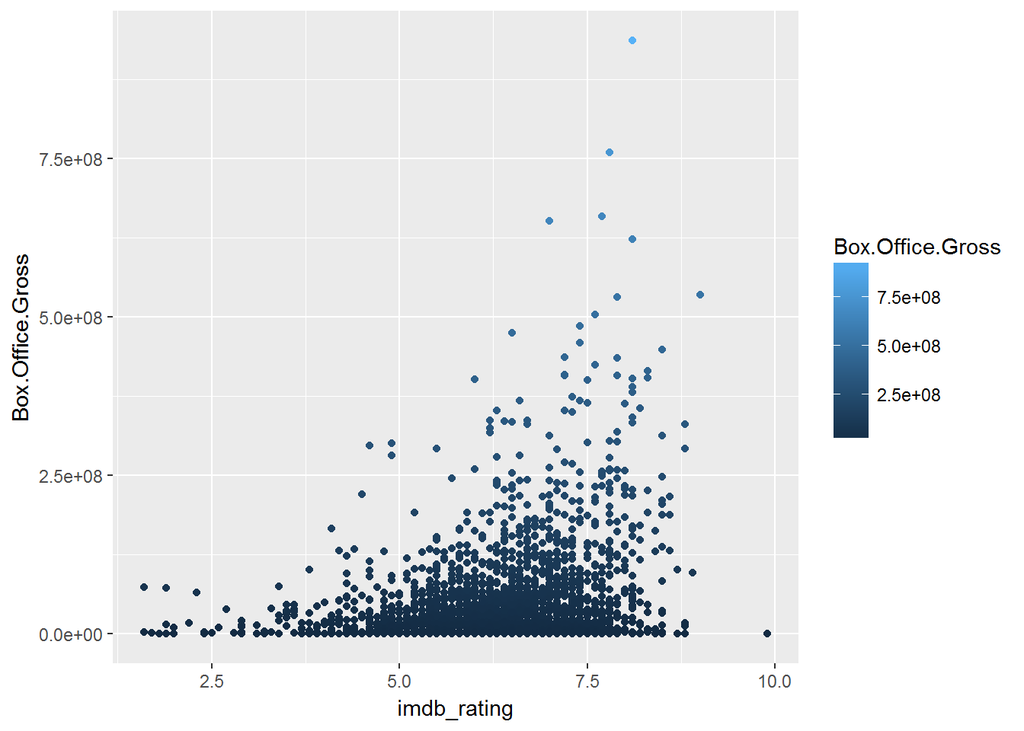

```r
movies.before %>%
  ggplot(aes(x=imdb_rating,y=Box.Office.Gross,col=Box.Office.Gross)) +
  geom_point()
```

2. Relationship of budget and box office gross:

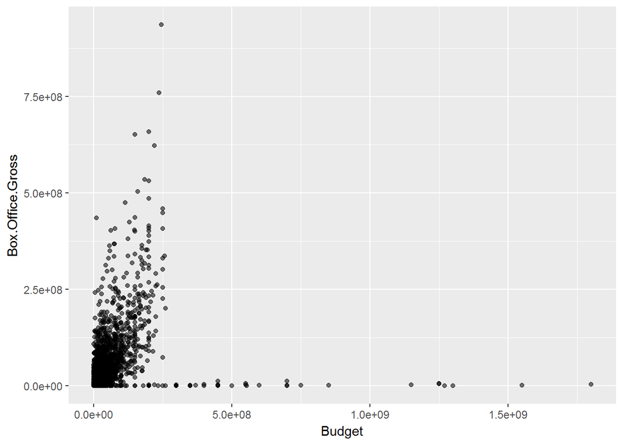

```r
# 2 outliers with extremly high busget
movies.before %>%
  filter(Budget<5000000000) %>%
  ggplot(aes(x=Budget,y=Box.Office.Gross,alpha=0.5))+
  geom_point(show.legend = FALSE)
```

Observe which movies have high budgets and low box office. Most of them win lots of awards and nominations. Probably more artistic and only appeal to a niche market than a blockbuster.

```r
movies.before %>%
  filter(Budget>250000000) %>%
  select(title,imdb_rating,release_date,production,actors,director,genre,awards,Budget,Box.Office.Gross,roi) %>%
  top_n(10)
```

```
##                       title imdb_rating release_date
## 1                   Tangled         7.8   2010-11-24
## 2           Bajirao Mastani         7.2   2015-12-18
## 3                    Dangal         8.8   2016-12-21
## 4              Spider-Man 3         6.2   2007-05-04
## 5              Jodhaa Akbar         7.6   2008-02-15
## 6                  3 Idiots         8.4   2009-12-25
## 7  Zindagi Na Milegi Dobara         8.1   2011-07-15
## 8                    Barfi!         8.1   2012-09-14
## 9                 Dabangg 2         4.9   2012-12-21
## 10                 Singam 2         6.3   2013-07-04
##                production
## 1    Walt Disney Pictures
## 2               SLB Films
## 3  Aamir Khan Productions
```

[output cut: 51 more lines]

When the budget is within reasonable amount, higher budget may bring more box office though not always the case.

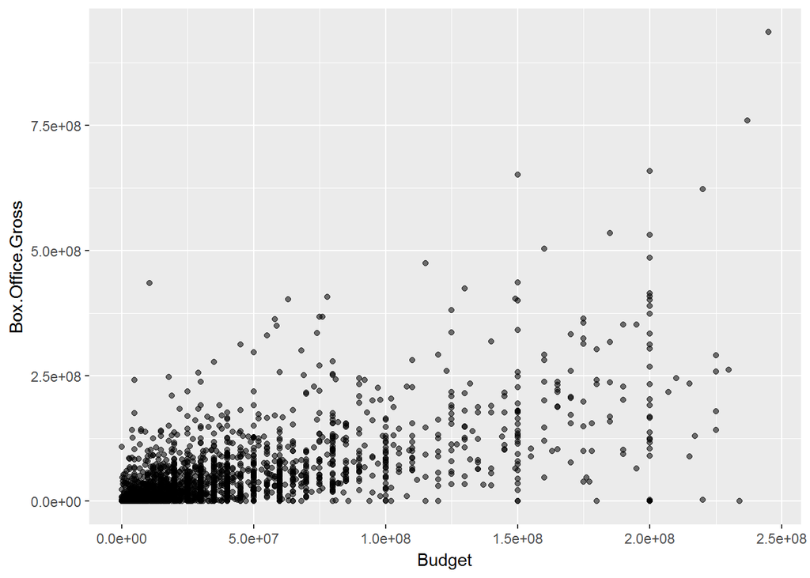

```r
#remove outliers to make the plot pattern clearer
movies.before %>%
  filter(Budget<250000000) %>%
  ggplot(aes(x=Budget,y=Box.Office.Gross,alpha=0.5))+
  geom_point(show.legend = FALSE)
```

3. Do certain genre lend themselves to higher return?

```r
genre <- movies.before %>%
  count(genre) %>%
  arrange(desc(n))
head(genre)
```

```
## # A tibble: 6 x 2
##   genre                      n
##   <fct>                  <int>
## 1 Drama                    145
## 2 Comedy, Drama            110
## 3 Comedy, Drama, Romance   109
## 4 Comedy                   107
## 5 Comedy, Romance           91
## 6 Drama, Romance            88
```

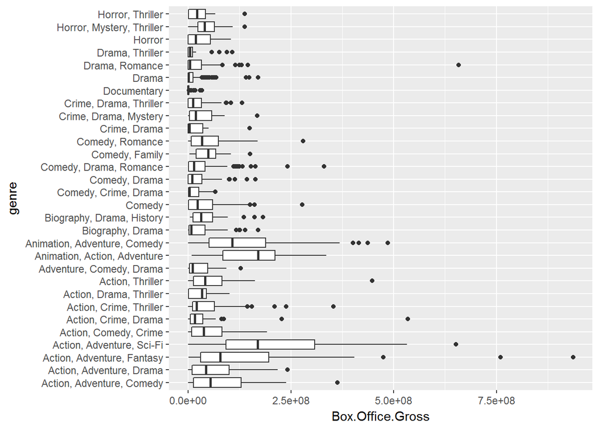

```r
movies.before %>%
  inner_join(genre[1:30,],by="genre") %>%
  ggplot(aes(x=genre,y=Box.Office.Gross))+
  geom_boxplot()+
  coord_flip()
```

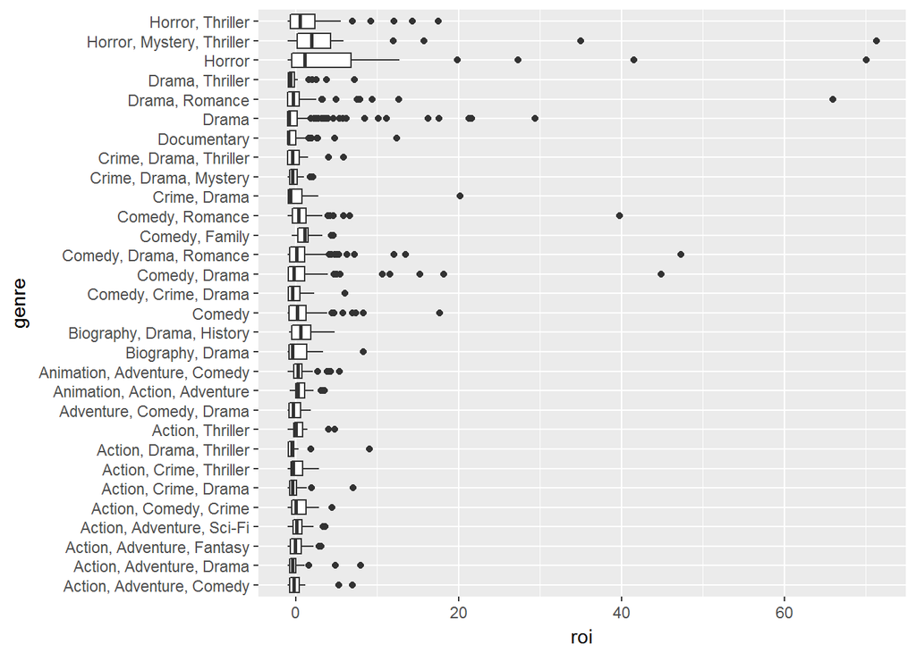

```r
#remove an outlier that has over 6000 roi in horror,mystery,thriller genre
movies.before %>%
  inner_join(genre[1:30,],by="genre") %>%
  filter(roi<100) %>%
  ggplot(aes(x=genre,y=roi))+
  geom_boxplot()+
  coord_flip()
```

Intersting and important Findings:

- Although there’re more than 300 segmented genres, it’s clear in the plot that they could be integrated into three main categories: comedy & romance & drama, horror & thriller & mystery, and action & adverture & crime. Sci-Fi and Documentary are in smaller amount so these two genres didn’t really stand out.
- In terms of box office gross, action > comedy > thriller. It makes sense that people like watching action movies because it’s exciting, and thriller is less relatable to the general public.
- In terms of roi, thriller > comedy > action. Action movie needs more resources to shoot and make the setting, while thriller is generally less cost-consuming.
4. Relationship of director and box office

```r
director <- movies.before %>%
  count(director,sort=TRUE)
head(director)
```

```
## # A tibble: 6 x 2
##   director              n
##   <fct>             <int>
## 1 Steven Spielberg     18
## 2 Ron Howard           13
## 3 Steven Soderbergh    10
## 4 Dennis Dugan          9
## 5 Robert Zemeckis       9
## 6 Spike Lee             9
```

This plot is sort by number of movies each director has in the dataset, because we’re more interested in well-known directors who have produced many award-winning movies. But it also means directors who has less movies might be left out in this plot.

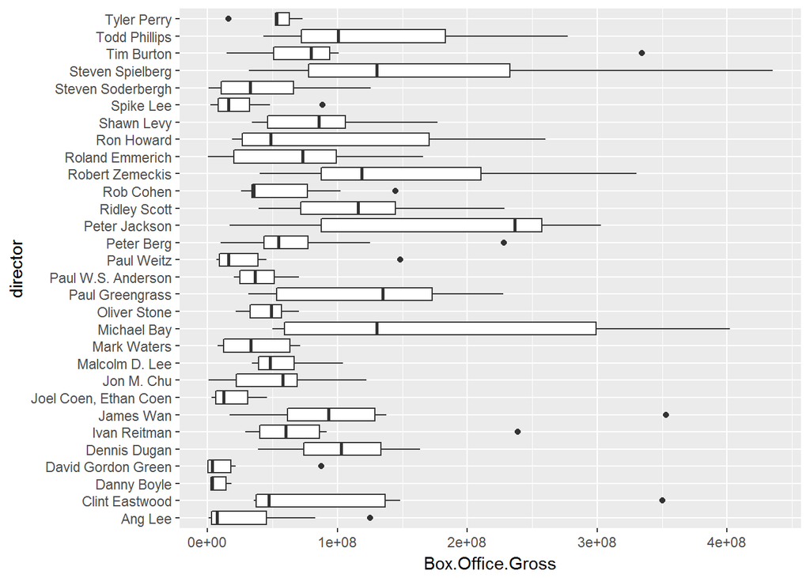

```r
movies.before %>%
  inner_join(director[1:30,],by="director") %>%
  ggplot(aes(x=director,y=Box.Office.Gross))+
  geom_boxplot()+
  coord_flip()
```

Observe what type of movies those directors with higher box office shot. (more of a genre issue or director issue.)

Jurassic Park series, ET, Schindler’s list, AI, Indiana Jones. Adventure, sci-fi, drama, war, history, action, biography

```r
movies.before %>%
  filter(director=="Steven Spielberg") %>%
  select(title,genre,Box.Office.Gross,roi)
```

```
##                                                 title
## 1                                       Jurassic Park
## 2                                             Lincoln
## 3                            The Adventures of Tintin
## 4                                           War Horse
## 5                                     Bridge of Spies
## 6                                             The BFG
## 7                                                1941
## 8                             Raiders of the Lost Ark
## 9                          E.T. the Extra-Terrestrial
## 10                                             Always
## 11                                   Schindler's List
## 12                      The Lost World: Jurassic Park
## 13                                Saving Private Ryan
## 14                       A.I. Artificial Intelligence
```

[output cut: 23 more lines]

Hobbit series and King Kong. Fantasy and adventure.

```r
movies.before %>%
  filter(director=="Peter Jackson") %>%
  select(title,genre,Box.Office.Gross,roi)
```

```
##                                       title                    genre
## 1                          The Lovely Bones Drama, Fantasy, Thriller
## 2         The Hobbit: An Unexpected Journey       Adventure, Fantasy
## 3       The Hobbit: The Desolation of Smaug       Adventure, Fantasy
## 4 The Hobbit: The Battle of the Five Armies       Adventure, Fantasy
## 5                           The Frighteners  Comedy, Fantasy, Horror
## 6                                 King Kong Action, Adventure, Drama
##   Box.Office.Gross         roi
## 1         43818839 -0.32586402
## 2        303003568  0.68335316
## 3        258366855  0.14829713
## 4        255119788  0.02047915
## 5         16759216 -0.44135947
## 6        218080025  0.05352669
```

Transformers series, action.

```r
movies.before %>%
  filter(director=="Michael Bay") %>%
  select(title,genre,Box.Office.Gross,roi)
```

```
##                                 title                     genre
## 1      Transformers: Dark of the Moon Action, Adventure, Sci-Fi
## 2                         Pain & Gain      Comedy, Crime, Drama
## 3     Transformers: Age of Extinction Action, Adventure, Sci-Fi
## 4       Transformers: The Last Knight Action, Adventure, Sci-Fi
## 5                            13 Hours    Action, Drama, History
## 6                            Bad Boys     Action, Comedy, Crime
## 7 Transformers: Revenge of the Fallen Action, Adventure, Sci-Fi
##   Box.Office.Gross         roi
## 1        352390543  0.80713099
## 2         49875291  0.91828042
## 3        245439076  0.16875750
## 4        130120862 -0.40036469
## 5         52853219  0.05706438
## 6         65807024  2.46352758
## 7        402111870  1.01055935
```

Titanic, Avatar, terminator. Action, sci-fi, adventure.

```r
movies.before %>%
  filter(director=="James Cameron") %>%
  select(title,genre,Box.Office.Gross,roi)
```

```
##                        title                      genre Box.Office.Gross
## 1                    Titanic             Drama, Romance        658672302
## 2 Terminator 2: Judgment Day   Action, Sci-Fi, Thriller        204843350
## 3                  True Lies   Action, Comedy, Thriller        146282411
## 4                     Avatar Action, Adventure, Fantasy        760507625
##        roi
## 1 2.293362
## 2 1.008268
## 3 0.272021
## 4 2.208893
```

Sum of box office of every director:

```r
movies.before %>%
  group_by(director) %>%
  summarize(total.box.office=sum(Box.Office.Gross)) %>%
  arrange(desc(total.box.office)) %>%
  top_n(10)
```

```
## # A tibble: 10 x 2
##    director          total.box.office
##    <fct>                        <dbl>
##  1 Steven Spielberg       3043002309.
##  2 James Cameron          1770305688.
##  3 Christopher Nolan      1629016219.
##  4 J.J. Abrams            1550175084.
##  5 Robert Zemeckis        1310841644.
##  6 Michael Bay            1298597885.
##  7 Ron Howard             1195612862.
##  8 Jon Favreau            1125727442.
##  9 Francis Lawrence       1102237551.
## 10 Bill Condon            1098592039.
```

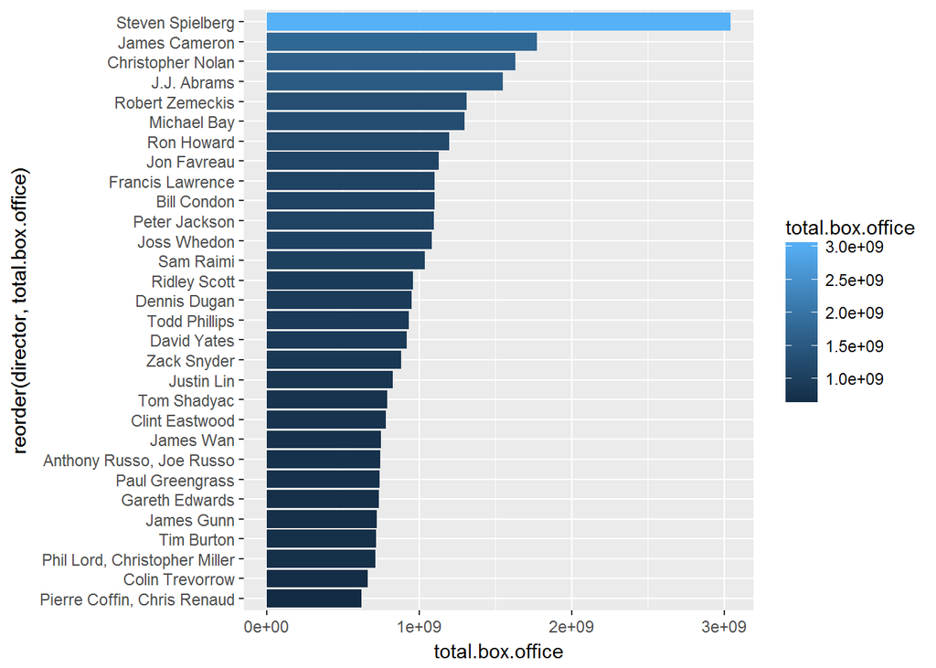

```r
movies.before %>%
  group_by(director) %>%
  summarize(total.box.office=sum(Box.Office.Gross)) %>%
  arrange(desc(total.box.office)) %>%
  top_n(30) %>%
  ggplot(aes(x=reorder(director,total.box.office),y=total.box.office,fill=total.box.office))+
  geom_col()+
  coord_flip()
```

James Cameron comes on top this time. He’s not as productive as spielberg, but he’s definitely the lucrative.

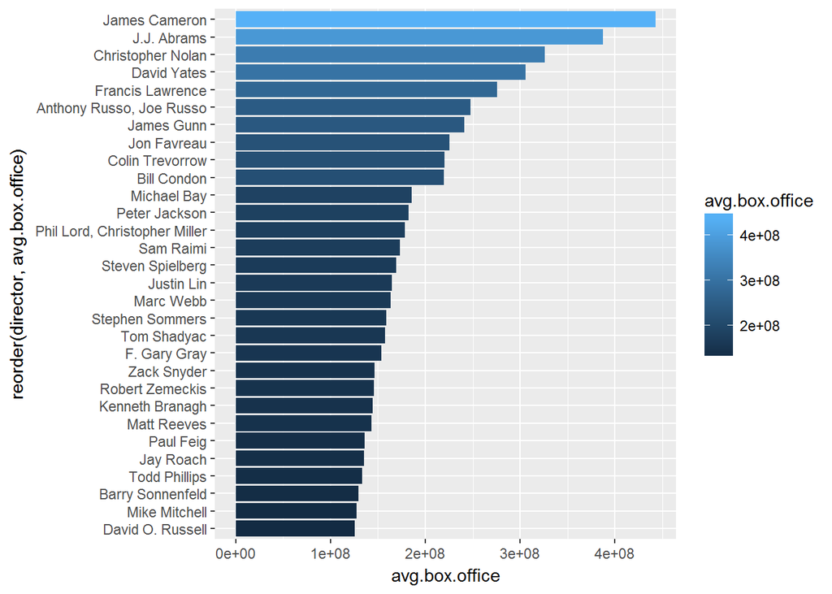

```r
#set filter because I want to eliminate directors who only have limited movie so his box office performance may not be stable to be trustworthy
movies.before %>%
  group_by(director) %>%
  filter(n()>=3) %>%
  summarize(avg.box.office=sum(Box.Office.Gross)/n()) %>%
  arrange(desc(avg.box.office)) %>%
  top_n(30) %>%
  ggplot(aes(x=reorder(director,avg.box.office),y=avg.box.office,fill=avg.box.office))+
  geom_col()+
  coord_flip()
```

Compare roi:

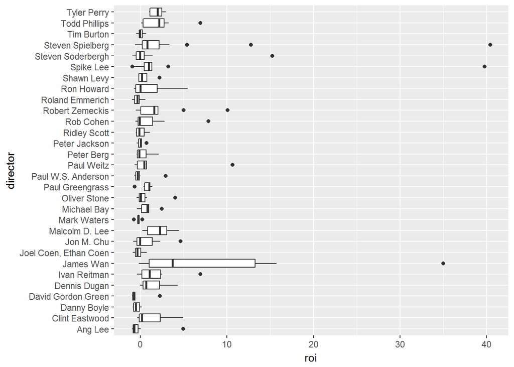

```r
# this is based on the number plot
movies.before %>%
  inner_join(director[1:30,],by="director") %>%
  ggplot(aes(x=director,y=roi))+
  geom_boxplot()+
  coord_flip()
```

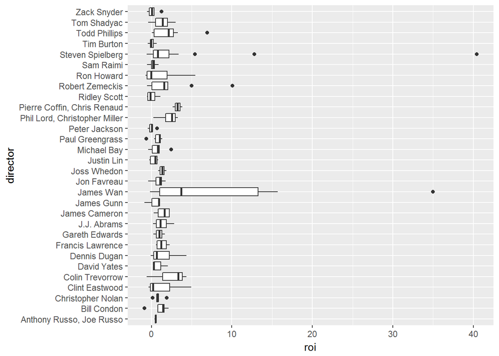

```r
# this is based on the total.box.office plot
total.box.office <- movies.before %>%
  group_by(director) %>%
  summarize(total.box.office=sum(Box.Office.Gross)) %>%
  arrange(desc(total.box.office))

movies.before %>%
  inner_join(total.box.office[1:30,],by="director") %>%
  ggplot(aes(x=director,y=roi))+
  geom_boxplot()+
  coord_flip()
```

5. timeline

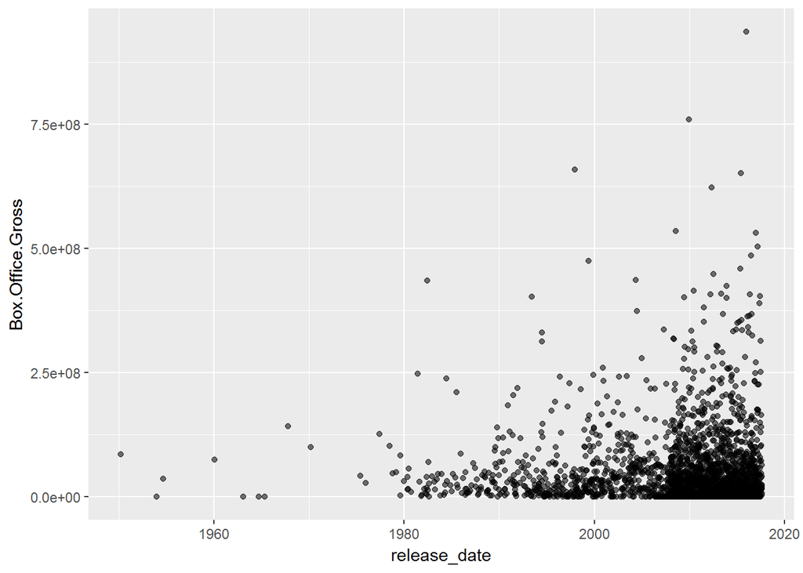

```r
movies.before %>%
  ggplot(aes(x=release_date,y=Box.Office.Gross,alpha=0.3))+
  geom_point(show.legend = FALSE)
```

see how many movies are released every year.

```r
movies.before %>%
  group_by(release.year) %>%
  summarize(count=n()) %>%
  top_n(10)
```

```
## # A tibble: 10 x 2
##    release.year count
##           <dbl> <int>
##  1        2008.   213
##  2        2009.   203
##  3        2010.   188
##  4        2011.   211
##  5        2012.   216
##  6        2013.   212
##  7        2014.   217
##  8        2015.   204
##  9        2016.   218
## 10        2017.    99
```

To observe how time of the year influence box office, we choose year between 1988-2017 since it has more data. The original idea is to plot every year as a line with points in 12 months (avg.box.office). But I ran into difficulties here. I’ll get back to it later.

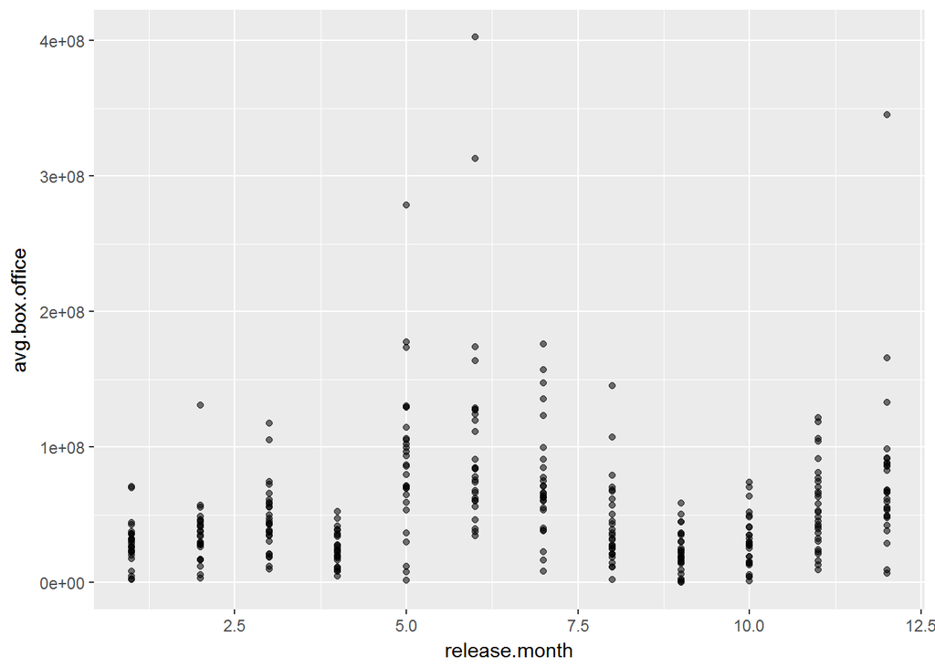

```r
movies.before %>%
  filter(release.year>=1988) %>%
  group_by(release.year,release.month) %>%
  summarize(count=n(),avg.box.office=sum(Box.Office.Gross)/count) %>%
  ggplot(aes(x=release.month,y=avg.box.office,alpha=0.3))+
  geom_point(show.legend = FALSE)
```

This time I don’t use average monthly box office, I put the box office of every movie here. The results are similar: movies released in May, June, July (summer time) and December tends to have more box office. It makes sense.

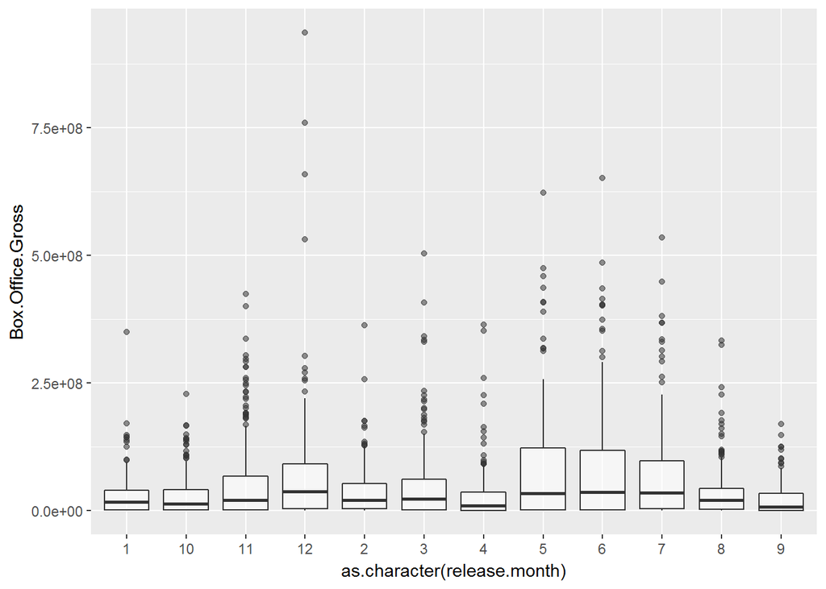

```r
movies.before %>%
  ggplot(aes(x=as.character(release.month),y=Box.Office.Gross,alpha=0.1))+
  geom_boxplot(show.legend = FALSE)
```

6. Do remakes (adaptions), tent-poles, and sequels perform differently?

Fitst step, find sequels. Sort the titles by alphabetical orders and you’ll find the sequels: 21/22 Jump Street, A Huanted House, Alvin and the Chipmunks, American Pie… But it’s time-consuming. A clever way would be to group by director, since a series of movies are always filmed by the same director.

```r
movies.before %>%
  group_by(title) %>%
  arrange(title) %>%
  top_n(10)
```

```
## # A tibble: 2,614 x 20
## # Groups:   title [2,595]
##    imdbid  title    rating imdb_rating metacritic dvd_release production
##    <fct>   <fct>    <fct>        <dbl>      <dbl> <date>      <fct>
##  1 tt1179~ 10 Clov~ PG-13         7.20        76. 2016-06-14  Bad Robot P~
##  2 tt3453~ 10 Days~ R             6.60       NaN  NA          N/A
##  3 tt0443~ 10,000 ~ PG-13         5.10        34. 2008-06-24  Warner Bros~
##  4 tt0488~ 12       PG-13         7.80        72. 2009-07-14  Sony Pictur~
##  5 tt1160~ 12 Roun~ PG-13         5.60        38. 2009-06-30  20th Centur~
##  6 tt2024~ 12 Year~ R             8.10        96. 2014-03-04  Fox Searchl~
##  7 tt1542~ 127 Hou~ R             7.60        82. 2011-03-01  Fox Searchl~
##  8 tt0337~ 13 Goin~ PG-13         6.10        57. 2006-02-07  Sony Pictur~
##  9 tt4172~ 13 Hours R             7.30        48. 2016-06-07  Paramount P~
## 10 tt2059~ 13 Sins  R             6.30        44. 2014-06-16  Radius-TWC
## # ... with 2,604 more rows, and 13 more variables: actors <fct>,
## #   imdb_votes <dbl>, director <fct>, release_date <date>, runtime <fct>,
## #   genre <fct>, awards <fct>, Budget <dbl>, Box.Office.Gross <dbl>,
## #   release.year <dbl>, release.month <dbl>, release.day <dbl>, roi <dbl>
```

I chose the top 50 director on the director dataframe sorted by the number of their films on the dataset, and sort it so it’s easier to spot the sequels, especailly the well-known ones.

I saw Twilight Saga, X-Men, Fast and Furious, Transformers, the Hobbit, Back to the future, Spider Man, Madea series, the hangover, Star war series, Jurassic Park series here.

```r
movies.before %>%
  inner_join(director[1:50,],by="director") %>%
  arrange(director) %>%
  top_n(10)
```

```
##       imdbid                                              title rating
## 1  tt0107290                                      Jurassic Park  PG-13
## 2  tt0443272                                            Lincoln  PG-13
## 3  tt0983193                           The Adventures of Tintin     PG
## 4  tt1568911                                          War Horse  PG-13
## 5  tt3682448                                    Bridge of Spies  PG-13
## 6  tt3691740                                            The BFG     PG
## 7  tt0078723                                               1941     PG
## 8  tt0082971                            Raiders of the Lost Ark     PG
## 9  tt0083866                         E.T. the Extra-Terrestrial     PG
## 10 tt0096794                                             Always     PG
## 11 tt0108052                                   Schindler's List      R
## 12 tt0119567                      The Lost World: Jurassic Park  PG-13
## 13 tt0120815                                Saving Private Ryan      R
## 14 tt0212720                       A.I. Artificial Intelligence  PG-13
```

[output cut: 137 more lines]

For adaptions, I saw Alice in Wonderland, Beauty and Beast, batman V superman, the three musketers, pride & prejudice here.

Select movie franchise for review.

1. star war series, 3 here.

```r
titles <- movies.before$title
star.war.index <- grep(pattern = "Star War", x=titles)
star.war <- movies.before[star.war.index,]
star.war %>%
  arrange(release_date) %>%
  select(title, release_date, imdb_rating, Budget, Box.Office.Gross, roi)
```

```
##                                       title release_date imdb_rating
## 1 Star Wars: Episode I - The Phantom Menace   1999-05-19         6.5
## 2                 Star Wars: The Clone Wars   2008-08-15         5.9
## 3              Star Wars: The Force Awakens   2015-12-18         8.1
##     Budget Box.Office.Gross      roi
## 1 1.15e+08        474544677 3.126475
## 2 8.50e+06         35161554 3.136653
## 3 2.45e+08        936662225 2.823111
```

2. Hobbit series, 3 here.

```r
hobbit.index <- grep(pattern = "Hobbit", x=titles)
hobbit <- movies.before[hobbit.index,]
hobbit %>%
  arrange(release_date) %>%
  select(title, release_date, imdb_rating, Budget, Box.Office.Gross, roi)
```

```
##                                       title release_date imdb_rating
## 1         The Hobbit: An Unexpected Journey   2012-12-14         7.9
## 2       The Hobbit: The Desolation of Smaug   2013-12-13         7.9
## 3 The Hobbit: The Battle of the Five Armies   2014-12-17         7.4
##     Budget Box.Office.Gross        roi
## 1 1.80e+08        303003568 0.68335316
## 2 2.25e+08        258366855 0.14829713
## 3 2.50e+08        255119788 0.02047915
```

3. Fast and Furious, 7 here.

```r
ff.index <- grep(pattern = "Furious", x=titles)
ff <- movies.before[ff.index,]
ff %>%
  arrange(release_date) %>%
  select(title, release_date, imdb_rating, Budget, Box.Office.Gross, roi)
```

```
##                                   title release_date imdb_rating  Budget
## 1              The Fast and the Furious   2001-06-22         6.7 3.8e+07
## 2                      2 Fast 2 Furious   2003-06-06         5.9 7.6e+07
## 3 The Fast and the Furious: Tokyo Drift   2006-06-16         6.0 8.5e+07
## 4                        Fast & Furious   2009-04-03         6.6 8.5e+07
## 5                      Fast & Furious 6   2013-05-24         7.1 1.6e+08
## 6                             Furious 7   2015-04-03         7.2 1.9e+08
## 7               The Fate of the Furious   2017-04-14         7.1 2.5e+08
##   Box.Office.Gross         roi
## 1        144533925  2.80352434
## 2        127154901  0.67309080
## 3         62514415 -0.26453629
## 4        155064265  0.82428547
## 5        238679850  0.49174906
## 6        353007020  0.85793168
## 7        225764765 -0.09694094
```

4. trnasformer series, 4 here.

```r
trans.index <- grep(pattern = "Transformers", x=titles)
transformers <- movies.before[trans.index,]
transformers %>%
  arrange(release_date) %>%
  select(title, release_date, imdb_rating, Budget, Box.Office.Gross, roi)
```

```
##                                 title release_date imdb_rating   Budget
## 1 Transformers: Revenge of the Fallen   2009-06-24         6.0 2.00e+08
## 2      Transformers: Dark of the Moon   2011-06-29         6.3 1.95e+08
## 3     Transformers: Age of Extinction   2014-06-27         5.7 2.10e+08
## 4       Transformers: The Last Knight   2017-06-21         5.5 2.17e+08
##   Box.Office.Gross        roi
## 1        402111870  1.0105594
## 2        352390543  0.8071310
## 3        245439076  0.1687575
## 4        130120862 -0.4003647
```

5. spiderman series, 5 here.

```r
spider.index <- grep(pattern = "Spider-Man", x=titles)
spiderman <- movies.before[spider.index,]
spiderman %>%
  arrange(release_date) %>%
  select(title, release_date, imdb_rating, Budget, Box.Office.Gross, roi)
```

```
##                      title release_date imdb_rating   Budget
## 1             Spider-Man 2   2004-06-30         7.3 2.00e+08
## 2             Spider-Man 3   2007-05-04         6.2 2.58e+08
## 3   The Amazing Spider-Man   2012-07-03         7.0 2.30e+08
## 4 The Amazing Spider-Man 2   2014-05-02         6.7 2.00e+08
## 5   Spider-Man: Homecoming   2017-07-07         NaN 1.75e+08
##   Box.Office.Gross        roi
## 1        373585825 0.86792912
## 2        336530303 0.30438102
## 3        262030663 0.13926375
## 4        202853933 0.01426967
## 5        314057748 0.79461570
```

6. Harry Potter series, only 2 here.

```r
hp.index <- grep(pattern = "Harry Potter", x=titles)
hp <- movies.before[hp.index,]
hp %>%
  arrange(release_date) %>%
  select(title, release_date, imdb_rating, Budget, Box.Office.Gross, roi)
```

```
##                                          title release_date imdb_rating
## 1       Harry Potter and the Half-Blood Prince   2009-07-15         7.5
## 2 Harry Potter and the Deathly Hallows: Part 2   2011-07-15         8.1
##     Budget Box.Office.Gross       roi
## 1 2.50e+08        301959197 0.2078368
## 2 1.25e+08        381011219 2.0480898
```

7. Jurassic Park, 3 here.

```r
jp.index <- grep(pattern = "Jurassic", x=titles)
jp <- movies.before[jp.index,]
jp %>%
  arrange(release_date) %>%
  select(title, release_date, imdb_rating, Budget, Box.Office.Gross, roi)
```

```
##                           title release_date imdb_rating  Budget
## 1                 Jurassic Park   1993-06-11         8.1 6.3e+07
## 2 The Lost World: Jurassic Park   1997-05-23         6.5 7.3e+07
## 3                Jurassic World   2015-06-12         7.0 1.5e+08
##   Box.Office.Gross      roi
## 1        402453882 5.388157
## 2        229086679 2.138174
## 3        652270625 3.348471
```

8. Batman, 3 here.

```r
bat.index <- grep(pattern = "Batman", x=titles)
batman <- movies.before[bat.index,]
batman %>%
  arrange(release_date) %>%
  select(title, release_date, imdb_rating, Budget, Box.Office.Gross, roi)
```

```
##                                title release_date imdb_rating  Budget
## 1 Batman v Superman: Dawn of Justice   2016-03-25         6.7 2.5e+08
## 2           Batman: The Killing Joke   2016-07-25         6.5 3.5e+06
## 3              The LEGO Batman Movie   2017-02-10         7.4 8.0e+07
##   Box.Office.Gross        roi
## 1        330360194 0.32144078
## 2          3775000 0.07857143
## 3        175750384 1.19687980
```

Adding all of these sequels into a dataframe:

```r
sequels <- rbind(ff,hobbit,hp,jp,spiderman,star.war,transformers,batman)

sequels$category <- NA
sequels$category[1:7] <- "FF"
sequels$category[8:10] <- "Hobbit"
sequels$category[11:12] <- "HP"
sequels$category[13:15] <- "JP"
sequels$category[16:20] <- "Spiderman"
sequels$category[21:23] <- "SW"
sequels$category[24:27] <- "Transformers"
sequels$category[28:30] <- "Batman"

sequels
```

```
##         imdbid                                        title rating
## 8    tt0232500                     The Fast and the Furious  PG-13
## 585  tt1905041                             Fast & Furious 6  PG-13
## 866  tt2820852                                    Furious 7  PG-13
## 1133 tt4630562                      The Fate of the Furious  PG-13
## 1646 tt0322259                             2 Fast 2 Furious  PG-13
## 1831 tt0463985        The Fast and the Furious: Tokyo Drift  PG-13
## 2090 tt1013752                               Fast & Furious  PG-13
## 96   tt0903624            The Hobbit: An Unexpected Journey  PG-13
## 172  tt1170358          The Hobbit: The Desolation of Smaug  PG-13
## 740  tt2310332    The Hobbit: The Battle of the Five Armies  PG-13
## 185  tt1201607 Harry Potter and the Deathly Hallows: Part 2  PG-13
## 1755 tt0417741       Harry Potter and the Half-Blood Prince     PG
## 4    tt0107290                                Jurassic Park  PG-13
## 11   tt0369610                               Jurassic World  PG-13
```

[output cut: 233 more lines]

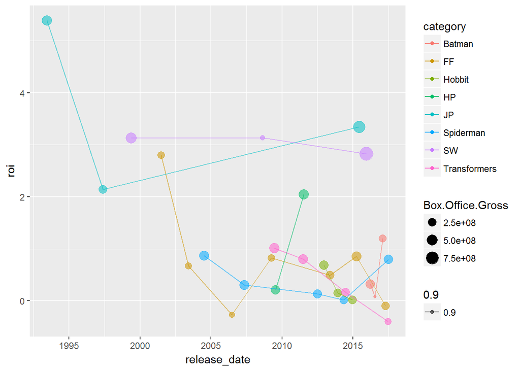

```r
#color <- c("#999999","#000000","#E69F00","#56B4E9","#009E73","#FF6600","#0072B2")

sequels %>%
  ggplot(aes(x=release_date,y=roi,col=category,alpha=0.9))+
  geom_point(aes(size=Box.Office.Gross))+
  geom_line()
```

For adaptions and remakes, there’re 2 adapted from fairy tales, and 2 from classic literature.

1. Alice in Wonderland

```r
alice.index <- grep(pattern = "Alice in Wonderland", x=titles)
alice <- movies.before[alice.index,]
alice %>%
  select(title, release_date, imdb_rating, Budget, Box.Office.Gross, roi)
```

```
##                   title release_date imdb_rating Budget Box.Office.Gross
## 120 Alice in Wonderland   2010-03-05         6.5  2e+08        334191110
##           roi
## 120 0.6709555
```

2. Beauty and Beast

```r
bb.index <- grep(pattern = "Beauty and the Beast", x=titles)
bb <- movies.before[bb.index,]
bb %>%
  select(title, release_date, imdb_rating, Budget, Box.Office.Gross, roi)
```

```
##                    title release_date imdb_rating  Budget Box.Office.Gross
## 3   Beauty and the Beast   1991-11-22         8.0 2.5e+07        218967620
## 860 Beauty and the Beast   2017-03-17         7.6 1.6e+08        504014165
##          roi
## 3   7.758705
## 860 2.150089
```

3. the Three Musketers

```r
musketeers.index <- grep(pattern = "Musketeers", x=titles)
musketeers <- movies.before[musketeers.index,]
musketeers %>%
  select(title, release_date, imdb_rating, Budget, Box.Office.Gross, roi)
```

```
##                    title release_date imdb_rating  Budget Box.Office.Gross
## 379 The Three Musketeers   2011-10-21         5.8 7.5e+07         20377913
##            roi
## 379 -0.7282945
```

4. Pride & Prejudice

```r
pp.index <- grep(pattern = "Pride & Prejudice", x=titles)
pp <- movies.before[pp.index,]
pp %>%
  arrange(release_date) %>%
  select(title, release_date, imdb_rating, Budget, Box.Office.Gross, roi)
```

```
##               title release_date imdb_rating  Budget Box.Office.Gross
## 1 Pride & Prejudice   2005-11-23         7.8 2.8e+07         38405088
##         roi
## 1 0.3716103
```

For adaptions and remakes, I think the box office and roi may be related to the popularity of the content and ratings. For some literary work that’s less well-known and may not be well produced, it’s natural that the roi is negative. So choosing the right Intellectual Property “IP” here is very important for remakes and adaptions, see Beauty and the Beast.

7. Actors Analysis

```r
movies.before %>%
  count(actors,sort=TRUE) %>%
  top_n(10)
```

```
## # A tibble: 14 x 2
##    actors                                                                n
##    <fct>                                                             <int>
##  1 N/A                                                                   7
##  2 Bradley Cooper, Ed Helms, Zach Galifianakis, Justin Bartha            3
##  3 Ian McKellen, Martin Freeman, Richard Armitage, Ken Stott             3
##  4 Adam Sandler, Andy Samberg, Selena Gomez, Kevin James                 2
##  5 Adam Sandler, Kevin James, Chris Rock, David Spade                    2
##  6 Ben Stiller, Chris Rock, David Schwimmer, Jada Pinkett Smith          2
##  7 Brendan Fraser, Rachel Weisz, John Hannah, Arnold Vosloo              2
##  8 Chris Hemsworth, Natalie Portman, Tom Hiddleston, Anthony Hopkins     2
##  9 Chris Pratt, Zoe Saldana, Dave Bautista, Vin Diesel                   2
## 10 Jennifer Lawrence, Josh Hutcherson, Liam Hemsworth, Woody Harrel~     2
## 11 Johnny Depp, Mia Wasikowska, Helena Bonham Carter, Anne Hathaway      2
## 12 Patrick Wilson, Rose Byrne, Ty Simpkins, Lin Shaye                    2
## 13 Prabhas, Rana Daggubati, Anushka Shetty, Tamannaah Bhatia             2
## 14 Sylvester Stallone, Jason Statham, Jet Li, Dolph Lundgren             2
```

Need to break down actor column into document term matrix to better analyze the relationship of actors and box office.

```r
library(tm)

# or first name and last name will be seperated into two items
actor <- as.character(movies.before$actors)
actor <- gsub(",", "   ", actor, fixed = TRUE)
actor <- gsub(" ", ".", actor, fixed = TRUE)
actor <- gsub("...", " ", actor, fixed = TRUE)
actor <- gsub(".", "", actor, fixed = TRUE)

actor.source <- VectorSource(actor)
actor.corpus <- VCorpus(actor.source)
actor.corpus.clean <- tm_map(actor.corpus,removePunctuation)

actor.dtm <- DocumentTermMatrix(actor.corpus.clean)
actor.matrix <- as.matrix(actor.dtm)

term.freq <- colSums(actor.matrix)
term.freq <- sort(term.freq,decreasing = TRUE)
head(term.freq,50)
```

```
##         robertdeniro             tomhanks          adamsandler
##                   23                   22                   21
##           liamneeson          stevecarell        dwaynejohnson
##                   20                   19                   18
##         jasonbateman         markwahlberg           naomiwatts
##                   18                   18                   18
##       robertdowneyjr          brucewillis        juliannemoore
##                   18                   17                   17
##            mattdamon   matthewmcconaughey           owenwilson
##                   17                   17                   17
##       woodyharrelson             amyadams      jenniferaniston
##                   17                   16                   16
##           johnnydepp arnoldschwarzenegger         jasonstatham
##                   16                   15                   15
##          jeffbridges          markruffalo          nicolascage
##                   15                   15                   15
##        susansarandon          alecbaldwin        bradleycooper
##                   15                   14                   14
##        channingtatum           danaykroyd          dennisquaid
##                   14                   14                   14
##           emilyblunt         ewanmcgregor        georgeclooney
##                   14                   14                   14
##          jamesfranco          jamesmcavoy         nicolekidman
##                   14                   14                   14
##         russellcrowe          willferrell             zacefron
##                   14                   14                   14
##         aaroneckhart         annakendrick           benstiller
##                   13                   13                   13
##        brendanfraser          camerondiaz      catherinekeener
##                   13                   13                   13
##           chrisevans            jackblack            jimcarrey
##                   13                   13                   13
##         juliaroberts         kevincostner
##                   13                   13
```

The Top 50 actors who appear in our dataset by number is Robert Deniro, Tom Hanks, Adam Sandler, Liam Neeson, Steve Carell and so on. There’re lots of big stars in this list including Robert Downey Jr, Julianne Moore, Matt Damon, Amy Adams, Jennifer Aniston, Johnny Depp, Arnold Schwarzenegger, Matthew McConaughey.

Due to the number of predictors is larger than the number of observations, we only include a limited number of actors here (keep the well-known ones to see if they have a direct association with box office) based on how many movies they played in in this dataset (>=10).

```r
actor.df.whole <- as.data.frame(actor.matrix)
```

```r
actor.df.selected <- actor.df.whole[,which(colSums(actor.df.whole)>=10)]
dim(actor.df.selected)
```

```
## [1] 2614  131
```

```r
actor.df.selected$box.office <- movies.before$Box.Office.Gross
actor.lm <- lm(box.office~.,data=actor.df.selected)
summary(actor.lm)
```

```
##
## Call:
## lm(formula = box.office ~ ., data = actor.df.selected)
##
## Residuals:
##        Min         1Q     Median         3Q        Max
## -202848306  -30052692  -18188670   12062006  769860221
##
## Coefficients:
##                       Estimate Std. Error t value Pr(>|t|)
## (Intercept)           30145745    1715412  17.573  < 2e-16 ***
## aaroneckhart          24482735   19799383   1.237 0.216375
## adamsandler           55636185   16732738   3.325 0.000897 ***
## alecbaldwin            6600281   19068486   0.346 0.729270
## alpacino              -9103502   20693246  -0.440 0.660029
## amyadams              38503562   18724037   2.056 0.039851 *
## angelinajolie         68050363   23590057   2.885 0.003952 **
## annakendrick          22589208   19788364   1.142 0.253755
## annettebening         -9052484   20914544  -0.433 0.665174
## anthonyhopkins         6265197   23377974   0.268 0.788725
## arnoldschwarzenegger  21646590   18211853   1.189 0.234711
## benaffleck            31107332   21846593   1.424 0.154602
## benkingsley           23118769   21889574   1.056 0.291000
## benstiller            71988585   20592446   3.496 0.000481 ***
## billmurray            22657254   22521108   1.006 0.314492
## billpaxton            33401767   22867407   1.461 0.144232
## billybobthornton     -14576189   22585166  -0.645 0.518736
## bradleycooper         45795972   20220994   2.265 0.023612 *
## bradpitt              28259276   21122084   1.338 0.181051
## brendanfraser         11455329   19726591   0.581 0.561492
## brendangleeson       -13185152   22966034  -0.574 0.565942
## brucewillis            9146458   17485771   0.523 0.600965
## camerondiaz           45631504   20019944   2.279 0.022734 *
## cateblanchett         38074803   20812552   1.829 0.067457 .
## catherinekeener       -9848902   20454047  -0.482 0.630194
## channingtatum         14741371   19437571   0.758 0.448286
## charlizetheron         8786342   22031874   0.399 0.690074
## chiwetelejiofor       29631248   22871924   1.296 0.195258
## chrisevans            90436457   21066472   4.293 1.83e-05 ***
## chrishemsworth        70517744   23105263   3.052 0.002297 **
```

[output cut: 93 more lines]

```
## tommyleejones         15657368   20959214   0.747 0.455110
## tomwilkinson           1832594   19815013   0.092 0.926320
## vincevaughn            2622735   21842242   0.120 0.904432
## vindiesel            160996598   21511537   7.484 9.94e-14 ***
## willarnett            72017928   23137153   3.113 0.001875 **
## willferrell           25521606   19395695   1.316 0.188350
## woodyharrelson        13229312   18005429   0.735 0.462567
## zacefron              12436672   19004122   0.654 0.512902
## zachgalifianakis      43334741   23710211   1.828 0.067717 .
## ---
## Signif. codes:  0 '***' 0.001 '**' 0.01 '*' 0.05 '.' 0.1 ' ' 1
##
## Residual standard error: 69660000 on 2482 degrees of freedom
## Multiple R-squared:  0.2113, Adjusted R-squared:  0.1697
## F-statistic: 5.077 on 131 and 2482 DF,  p-value: < 2.2e-16
```

```r
keep.actor <- c("zachgalifianakis","willarnett","vindiesel","tomhanks","tomcruise","stevecarell","scarlettjohansson","ryanreynolds","robertdowneyjr","ralphfiennes","natalieportman","mattdamon","matthewmcconaughey","markwahlberg","kristenwiig","liamneeson","kristenstewart","kirstendunst","kevinhart","johnnydepp","josephgordonlevitt","johngoodman","jasonbateman","jenniferlawrence","jimcarrey","jamesfranco","hughjackman","harrisonford","gerardbutler","adamsandler","amyadams","angelinajolie","benstiller","bradleycooper","camerondiaz","cateblanchett","chrisevans","chrishemsworth","chrispine","dwaynejohnson","eddiemurphy","emmastone")

actor.coeffi <- data.frame(actor=keep.actor, influence.coefficient=actor.lm$coefficients[keep.actor])
head(actor.coeffi)
```

```
##                             actor influence.coefficient
## zachgalifianakis zachgalifianakis              43334741
## willarnett             willarnett              72017928
## vindiesel               vindiesel             160996598
## tomhanks                 tomhanks             102993538
## tomcruise               tomcruise              75886829
## stevecarell           stevecarell              50841083
```

```r
dim(actor.coeffi)
```

```
## [1] 42  2
```

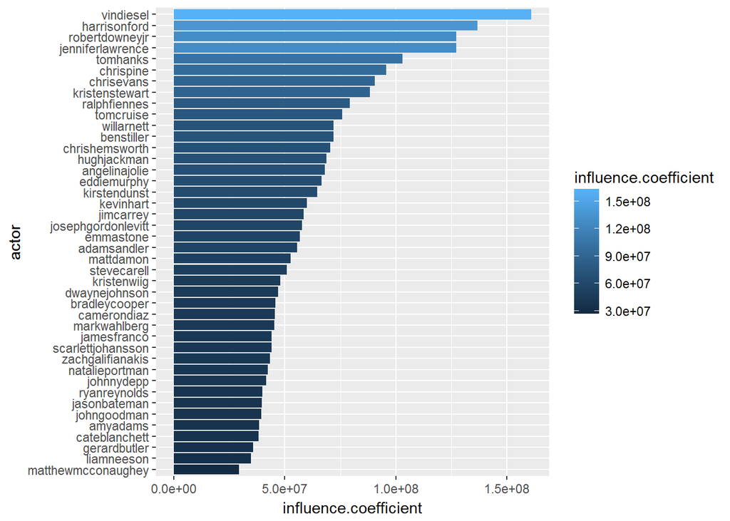

```r
actor.coeffi %>%
  ggplot(aes(x=reorder(actor,influence.coefficient),y=influence.coefficient,fill=influence.coefficient))+
  geom_col()+
  coord_flip()+
  labs(x="actor")
```

All actors that have significant influence over box office have positive coefficients here. The top 5 actors who could bring considerable amount of box office are Vin Diesel, Harrison Ford, Robert Downey Jr, Jennifer Lawrence, and Tom Hanks. Generally speaking more actors than actresses make it to this graph, and this may have something to do with Hollywood’s unfair payment between gender.

8. Does a movie’s rating influence its box office?

```r
table(movies.before$rating)
```

```
##
##            APPROVED         G         M       N/A     NC-17 NOT RATED
##         0         2        47         0       142         3        88
##        NR        PG     PG-13         R     TV-14      TV-G     TV-MA
##         1       345       888      1071         0         0         0
##     TV-PG      TV-Y   Unrated   UNRATED         X
##         1         0         0        25         1
```

The three most common ratings are R, PG-13, PG here, so we’ll only analyze the difference among these three.

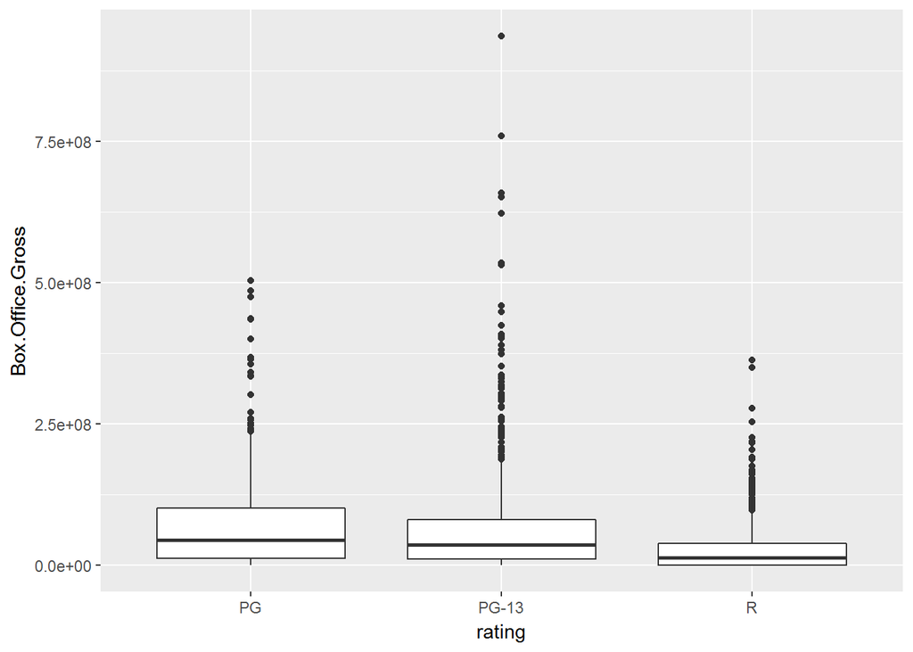

```r
movies.before %>%
  filter(rating %in% c("R","PG","PG-13")) %>%
  group_by(rating) %>%
  ggplot(aes(x=rating,y=Box.Office.Gross))+
  geom_boxplot()
```

R rating movies mostly have lower box office than PG-13 and PG. It’s easy to understand since higher restriction level limits the audience.

9. Why do some small budge films end up being blockbuster hits? Conversely, why do some large budge films fail?

We filter out movies that have top 10 roi and bottom 10 roi to find a pattern.

```r
movies.before %>%
  arrange(desc(roi)) %>%
  top_n(10)
```

```
##       imdbid                    title rating imdb_rating metacritic
## 1  tt1179904      Paranormal Activity      R         6.3         68
## 2  tt3320578                   Veeram    N/A         6.7        NaN
## 3  tt5481184           League of Gods  PG-13         4.6        NaN
## 4  tt2309260              The Gallows      R         4.2         30
## 5  tt0077651                Halloween      R         7.8         78
## 6  tt0080761          Friday the 13th      R         6.5         19
## 7  tt1560985         The Devil Inside      R         4.2         18
## 8  tt1129423                Fireproof     PG         6.6         28
## 9  tt0259446 My Big Fat Greek Wedding     PG         6.6         62
## 10 tt0088847       The Breakfast Club      R         7.9         62
##    dvd_release                     production
## 1   2009-12-29             Paramount Pictures
## 2         <NA>               AIM Distribution
## 3         <NA>                            N/A
```

[output cut: 62 more lines]

By observation, it’s noticed that for movies that have high roi, they mostly have low budget, not-so-well-known director and actors, but have some nominations and awards. And half of them are horror+thriller genre.

```r
movies.before %>%
  arrange(roi) %>%
  top_n(-10)
```

```
##       imdbid                            title    rating imdb_rating
## 1  tt1606384                           My Way         R         7.8
## 2  tt4832640                           Sultan NOT RATED         7.1
## 3  tt2557256                           Iceman         R         4.8
## 4  tt2215077             Half of a Yellow Sun         R         6.2
## 5  tt1487931                           Khumba NOT RATED         5.8
## 6  tt0273689              It's All About Love         R         5.5
## 7  tt0485947                       Mr. Nobody         R         7.9
## 8  tt2275471                    A Perfect Man         R         5.2
## 9  tt1857913 The Sorcerer and the White Snake     PG-13         5.9
## 10 tt1410063               The Flowers of War         R         7.6
##    metacritic dvd_release                production
## 1          30  2012-07-23          CJ Entertainment
## 2         NaN        <NA>            Yash Raj Films
## 3          32  2014-11-11               Well Go USA
```

[output cut: 62 more lines]

For movies that have low roi, their budget is high and box office failed to make ends meet. Half of them are action movies and half are drama+romance. Action movie is usually more costly than other genre as we mentioned above.

## PREDICTIVE MODELING

1. In order to do Linear Regression, we don’t want useless columns including title, imdbid, dvd_release, release_date (keep seperate release info) and roi so we only keep the useful numeric columns as predictors.

```r
keep <- c("imdb_rating","metacritic","imdb_votes","Budget","Box.Office.Gross","release.year","release.month")
movies.clean <- movies.before[keep]
```

```r
head(movies.clean)
```

```
##   imdb_rating metacritic imdb_votes  Budget Box.Office.Gross release.year
## 1         7.2        NaN      17801 2.2e+05            46585         1965
## 2         7.8         67     289586 3.0e+07        238632124         1984
## 3         8.0         95     332843 2.5e+07        218967620         1991
## 4         8.1         68     665919 6.3e+07        402453882         1993
## 5         8.8         82    1365937 5.5e+07        330252182         1994
## 6         7.7         74     847267 2.0e+08        658672302         1997
##   release.month
## 1             5
## 2             6
## 3            11
## 4             6
## 5             7
## 6            12
```

3. For runtime column we remove the “min” and transform it into numeric type.

```r
for (i in 1:nrow(movies.before)){
  movies.clean$runtime[i] <- as.numeric(strsplit(as.character(movies.before$runtime),split=" ")[[i]][1])
}
```

4. For other categorical columns including rating, production, actors, director, genre, awards, keywords, we will use bag of words method to create a dtm and add these dummy variable to train.clean.

```r
library(tm)
```

4.1 Genre

```r
genre <- as.character(movies.before$genre)
head(genre,5)
```

```
## [1] "Drama, Mystery, Sci-Fi"      "Action, Adventure, Comedy"
## [3] "Animation, Family, Fantasy"  "Adventure, Sci-Fi, Thriller"
## [5] "Comedy, Drama, Romance"
```

```r
genre.source <- VectorSource(genre)
genre.corpus <- VCorpus(genre.source)
print(genre.corpus[[1]][1])
```

```
## $content
## [1] "Drama, Mystery, Sci-Fi"
```

Create a clean_corpus function.

```r
clean_corpus <- function(corpus){
  corpus <- tm_map(corpus,removePunctuation)
  return(corpus)
}
```

```r
genre.corpus.clean <- clean_corpus(genre.corpus)
print(genre.corpus.clean[[1]][1])
```

```
## $content
## [1] "Drama Mystery SciFi"
```

```r
genre.dtm <- DocumentTermMatrix(genre.corpus.clean)
genre.matrix <- as.matrix(genre.dtm)
dim(genre.matrix)
```

```
## [1] 2614   23
```

```r
genre.matrix[1:5,1:23]
```

```
##     Terms
## Docs action adventure animation biography comedy crime documentary drama
##    1      0         0         0         0      0     0           0     1
##    2      1         1         0         0      1     0           0     0
##    3      0         0         1         0      0     0           0     0
##    4      0         1         0         0      0     0           0     0
##    5      0         0         0         0      1     0           0     1
##     Terms
## Docs family fantasy history horror music musical mystery news romance
##    1      0       0       0      0     0       0       1    0       0
##    2      0       0       0      0     0       0       0    0       0
##    3      1       1       0      0     0       0       0    0       0
##    4      0       0       0      0     0       0       0    0       0
##    5      0       0       0      0     0       0       0    0       1
##     Terms
## Docs scifi short sport thriller war western
##    1     1     0     0        0   0       0
##    2     0     0     0        0   0       0
##    3     0     0     0        0   0       0
##    4     1     0     0        1   0       0
##    5     0     0     0        0   0       0
```

```r
term.freq <- colSums(genre.matrix)
term.freq <- sort(term.freq,decreasing = TRUE)
term.freq
```

```
##       drama      comedy      action   adventure     romance    thriller
##        1320         965         633         486         451         423
##       crime      horror     mystery     fantasy       scifi   biography
##         413         245         212         200         183         177
##      family   animation documentary       music     history       sport
##         169         142          98          80          75          61
##         war     musical     western        news       short
##          41          22          15           4           1
```

```r
keep.genre <- c("action","adventure","comedy","drama","romance","fantasy","horror","thriller","mystery","scifi","crime")
genre.df <- as.data.frame(genre.matrix)[keep.genre]
head(genre.df)
```

```
##   action adventure comedy drama romance fantasy horror thriller mystery
## 1      0         0      0     1       0       0      0        0       1
## 2      1         1      1     0       0       0      0        0       0
## 3      0         0      0     0       0       1      0        0       0
## 4      0         1      0     0       0       0      0        1       0
## 5      0         0      1     1       1       0      0        0       0
## 6      0         0      0     1       1       0      0        0       0
##   scifi crime
## 1     1     0
## 2     0     0
## 3     0     0
## 4     1     0
## 5     0     0
## 6     0     0
```

4.2 Actor

```r
actor.df <- as.data.frame(actor.matrix)[keep.actor]
head(actor.df)
```

```
##   zachgalifianakis willarnett vindiesel tomhanks tomcruise stevecarell
## 1                0          0         0        0         0           0
## 2                0          0         0        0         0           0
## 3                0          0         0        0         0           0
## 4                0          0         0        0         0           0
## 5                0          0         0        1         0           0
## 6                0          0         0        0         0           0
##   scarlettjohansson ryanreynolds robertdowneyjr ralphfiennes
## 1                 0            0              0            0
## 2                 0            0              0            0
## 3                 0            0              0            0
## 4                 0            0              0            0
## 5                 0            0              0            0
## 6                 0            0              0            0
##   natalieportman mattdamon matthewmcconaughey markwahlberg kristenwiig
```

[output cut: 41 more lines]

4.3 Production

```r
production <- as.character(movies.before$production)
production <- gsub(" ","",production,fixed=TRUE)
production.source <- VectorSource(production)
production.corpus <- VCorpus(production.source)

production.dtm <- DocumentTermMatrix(production.corpus)
production.matrix <- as.matrix(production.dtm)

term.freq <- colSums(production.matrix)
term.freq <- sort(term.freq,decreasing = TRUE)
head(term.freq,20)
```

```
##     universalpictures   warnerbros.pictures        20thcenturyfox
##                   263                   140                   134
##          sonypictures     paramountpictures                   n/a
##                   109                    96                    69
##    waltdisneypictures mcauniversalhomevideo         focusfeatures
##                    69                    64                    62
##        lionsgatefilms  sonypicturesclassics              ifcfilms
##                    51                    44                    41
##      magnoliapictures   theweinsteincompany             lionsgate
##                    41                    40                    38
##   summitentertainment      columbiapictures       relativitymedia
##                    35                    33                    31
##   roadsideattractions         openroadfilms
##                    30                    29
```

```r
keep.production <- c("universalpictures","warnerbros.pictures","20thcenturyfox","sonypictures","paramountpictures","waltdisneypictures","focusfeatures","lionsgatefilms","sonypicturesclassics","columbiapictures")
production.df <- as.data.frame(production.matrix)[keep.production]
```

4.4 Director

```r
director <- as.character(movies.before$director)
director <- gsub(" ","",director,fixe=TRUE)
director.source <- VectorSource(director)
director.corpus <- VCorpus(director.source)

director.dtm <- DocumentTermMatrix(director.corpus)
director.matrix <- as.matrix(director.dtm)

term.freq <- colSums(director.matrix)
term.freq <- sort(term.freq,decreasing = TRUE)
```

```r
head(term.freq,70)
```

```
##    stevenspielberg          ronhoward   stevensoderbergh
##                 18                 13                 10
##        dennisdugan     robertzemeckis           spikelee
##                  9                  9                  9
##        oliverstone          peterberg        ridleyscott
##                  8                  8                  8
##             anglee      clinteastwood           jonm.chu
##                  7                  7                  7
##         michaelbay   paulw.s.anderson           robcohen
##                  7                  7                  7
##     rolandemmerich          shawnlevy          timburton
##                  7                  7                  7
##       toddphillips         tylerperry         dannyboyle
##                  7                  7                  6
##   davidgordongreen        ivanreitman           jameswan
##                  6                  6                  6
## joelcoen,ethancoen       malcolmd.lee         markwaters
##                  6                  6                  6
##     paulgreengrass          paulweitz       peterjackson
##                  6                  6                  6
##   richardlinklater          robreiner           samraimi
##                  6                  6                  6
##         woodyallen         zacksnyder       antoinefuqua
##                  6                  6                  5
##      barrylevinson         billcondon        bryansinger
##                  5                  5                  5
##   christophernolan         d.j.caruso         davidkoepp
##                  5                  5                  5
##         davidlynch ethancoen,joelcoen      garrymarshall
##                  5                  5                  5
##      goreverbinski         gusvansant       jasonreitman
##                  5                  5                  5
##          joewright      johncarpenter         jonfavreau
##                  5                  5                  5
##         juddapatow          justinlin     kathrynbigelow
##                  5                  5                  5
##         petersegal   quentintarantino      robertluketic
##                  5                  5                  5
##    robertschwentke     rogerdonaldson          sammendes
##                  5                  5                  5
##       sofiacoppola     taylorhackford         tomshadyac
##                  5                  5                  5
##          wescraven          adammckay       annefletcher
##                  5                  4                  4
##        brettratner       briandepalma     brianhelgeland
##                  4                  4                  4
##        brianlevant
##                  4
```

```r
keep.director <- c("stevenspielberg","jamescameron","christophernolan","woodyallen","ronhoward","robertzemeckis","stevensoderbergh","dennisdugan","spikelee","oliverstone","peterberg","ridleyscott","anglee","robcohen","timburton","jameswan","michaelbay","clinteastwood","tylerperry","peterjackson","ethancoen,joelcoen","davidlynch","joewright","sofiacoppola")
director.df <- as.data.frame(director.matrix)[keep.director]
```

4.5 Award and nominaton

Here the infos about awards and nomination has been reduced to four columns: nomination, oscar, golden globe, and award. Numbers of awards and nominations are not included for simplicity reason.

```r
library(textreg)
```

```r
award <- as.character(movies.before$awards)
award.source <- VectorSource(award)
award.corpus <- VCorpus(award.source)

# clean and stem corpus
award.corpus <- tm_map(award.corpus,removePunctuation)
award.corpus <- tm_map(award.corpus,removeNumbers)
award.corpus <- tm_map(award.corpus,content_transformer(tolower))
award.corpus <- stem.corpus(award.corpus,verbose=FALSE)

award.dtm <- DocumentTermMatrix(award.corpus)
award.matrix <- as.matrix(award.dtm)

term.freq <- colSums(award.matrix)
term.freq <- sort(term.freq,decreasing = TRUE)
term.freq
```

```
## nomin+   win+ anoth+ oscar+    for    won globe+ golden award+  bafta
##   2434   1640    516    382    379    137    108    108     26     26
##   film
##     26
```

```r
keep.award <- c("nomin+","oscar+","globe+","award+")
award.df <- as.data.frame(award.matrix)[keep.award]
colnames(award.df) <- c("nomination","oscar","golden globe","award")
```

4.6 Keyword

```r
# keyword <- as.character(movies.before$keywords) executed above
keyword <- gsub("|"," ",keyword,fixe=TRUE)
keyword <- gsub("-"," ",keyword,fixe=TRUE)

keyword.source <- VectorSource(keyword)
keyword.corpus <- VCorpus(keyword.source)
keyword.corpus <- tm_map(keyword.corpus,removeWords,stopwords("en"))

keyword.dtm <- DocumentTermMatrix(keyword.corpus)
keyword.matrix <- as.matrix(keyword.dtm)

term.freq <- colSums(keyword.matrix)
term.freq <- sort(term.freq,decreasing = TRUE)
head(term.freq,100)
```

```
##    reference relationship        death         shot        title
##         5719         5611         4270         4234         4083
##          car       female        woman          man    character
##         3961         3380         2953         2666         2495
##       police         male          sex       father        scene
##         2463         2308         2124         2112         1993
##       nudity       mother        blood         face          son
##         1827         1804         1778         1743         1739
##       murder      stabbed          gun         head          new
##         1699         1692         1689         1653         1636
##       camera         word        child     daughter     american
##         1549         1453         1415         1320         1319
##         film        chase        based         girl         city
##         1317         1316         1312         1311         1292
##         wife          one         hand         york         fire
##         1284         1264         1252         1223         1210
##         year      brother       school        chest        fight
##         1210         1205         1173         1166         1137
##         bare         hero      credits      falling      husband
##         1136         1127         1125         1122         1114
##         dead        black         body     violence    exploding
##         1087         1075         1072         1046         1034
##          dog         love       family        knife          boy
##         1032         1024          986          963          960
##          hit         kiss        phone      someone         name
##          959          945          943          920          878
##    flashback      officer       animal      opening          war
##          869          849          828          825          824
##   friendship         loss       friend        party       sister
##          821          820          816          803          798
##      chested      smoking         back      punched    explosion
##          787          780          770          764          753
##       window       pistol         self      panties      teenage
##          752          743          743          718          714
##   helicopter        train       motion       secret         drug
##          708          699          694          687          683
##          leg       ending     surprise         cell          gay
##          682          681          679          676          676
##        agent      machine       spoken          two      suicide
##          675          666          665          661          657
```

```r
keep.keyword <- c("relationship","death","shot","car","female","woman","man","male","police","sex","nudity","blood","gun","murder","hero","father","mother","son","american","daughter","child","wife","fight","school","husband","violence","love","family","dog","war","animal","friendship","teenage")
keyword.df <- as.data.frame(keyword.matrix)[keep.keyword]
head(keyword.df)
```

```
##   relationship death shot car female woman man male police sex nudity
## 1            0     0    0   1      0     0   0    0      0   0      1
## 2            0     0    1   0      1     1   2    0      0   1      0
## 3            8     2    2   0      4     1   2    2      0   0      0
## 4            3     1    0   2      2     0   3    2      0   0      0
## 5            1     2    0   0      3     4   5    4      0   1      2
## 6            2     9    3   8      9     7   4    3      0  11      8
##   blood gun murder hero father mother son american daughter child wife
## 1     0   1      0    1      0      0   0        0        0     0    0
## 2     0   1      0    1      0      0   0        0        0     0    0
## 3     0   0      0    2      1      1   1        0        1     0    0
## 4     0   0      0    1      0      0   0        0        0     3    0
## 5     0   0      0    1      1      6   2        0        0     2    0
## 6     0   1      1    1      0      2   0        2        1     1    1
##   fight school husband violence love family dog war animal friendship
## 1     0      0       0        3    0      0   0   0      0          0
## 2     0      0       0        0    0      0   0   1      0          1
## 3     1      0       0        0    4      0   2   0      8          0
## 4     0      0       0        1    0      0   0   0      2          0
## 5     1      2       0        0    0      1   0   4      0          3
## 6     0      0       0        2    9      0   1   0      0          1
##   teenage
## 1       0
## 2       0
## 3       0
## 4       1
## 5       0
## 6       2
```

4.7 Rating

I don’t know why some ratings in corpus cannot be transalted into dtm. Just ignore it for now

```r
rating <- as.character(movies.before$rating)
head(rating,10)
```

```
##  [1] "NOT RATED" "PG"        "G"         "PG-13"     "PG-13"
##  [6] "PG-13"     "PG"        "PG-13"     "PG"        "R"
```

```r
rating.source <- VectorSource(rating)
rating.corpus <- VCorpus(rating.source)

table(movies.before$rating)
```

```
##
##            APPROVED         G         M       N/A     NC-17 NOT RATED
##         0         2        47         0       142         3        88
##        NR        PG     PG-13         R     TV-14      TV-G     TV-MA
##         1       345       888      1071         0         0         0
##     TV-PG      TV-Y   Unrated   UNRATED         X
##         1         0         0        25         1
```

```r
for (i in 1:20){
  print(rating.corpus[[i]][1])
}
```

```
## $content
## [1] "NOT RATED"
##
## $content
## [1] "PG"
##
## $content
## [1] "G"
##
## $content
## [1] "PG-13"
##
## $content
## [1] "PG-13"
##
## $content
## [1] "PG-13"
##
## $content
## [1] "PG"
##
## $content
## [1] "PG-13"
##
## $content
## [1] "PG"
##
## $content
## [1] "R"
##
## $content
## [1] "PG-13"
##
## $content
## [1] "R"
##
## $content
## [1] "G"
##
## $content
## [1] "PG-13"
##
## $content
## [1] "PG"
##
## $content
## [1] "PG-13"
##
## $content
## [1] "R"
##
## $content
## [1] "PG-13"
##
## $content
## [1] "PG-13"
##
## $content
## [1] "PG-13"
```

```r
rating.dtm <- DocumentTermMatrix(rating.corpus)
rating.matrix <- as.matrix(rating.dtm)
dim(rating.matrix)
```

```
## [1] 2614    8
```

```r
head(rating.matrix)
```

```
##     Terms
## Docs approved n/a nc-17 not pg-13 rated tv-pg unrated
##    1        0   0     0   1     0     1     0       0
##    2        0   0     0   0     0     0     0       0
##    3        0   0     0   0     0     0     0       0
##    4        0   0     0   0     1     0     0       0
##    5        0   0     0   0     1     0     0       0
##    6        0   0     0   0     1     0     0       0
```

5. Combine these dataframes together

```r
dim(movies.clean)
```

```
## [1] 2614    8
```

```r
dim(actor.df)
```

```
## [1] 2614   42
```

```r
dim(award.df)
```

```
## [1] 2614    4
```

```r
dim(director.df)
```

```
## [1] 2614   24
```

```r
dim(genre.df)
```

```
## [1] 2614   11
```

```r
dim(keyword.df)
```

```
## [1] 2614   33
```

```r
dim(production.df)
```

```
## [1] 2614   10
```

```r
movies.clean.df <- cbind(movies.clean,actor.df,award.df,director.df,genre.df,keyword.df,production.df)
dim(movies.clean.df)
```

```
## [1] 2614  132
```

```r
write.csv(movies.clean.df,"movies_clean.csv")
```

6. split into train and test set for model validation.

Find NAs and in movies.clean.df in imdb_rating, matacritic, imdb_votes, and runtime.

```r
summary(movies.clean.df)
```

```
##   imdb_rating      metacritic      imdb_votes          Budget
##  Min.   :1.600   Min.   :  1.0   Min.   :     17   Min.   :4.400e+01
##  1st Qu.:5.800   1st Qu.: 41.0   1st Qu.:   9142   1st Qu.:7.000e+06
##  Median :6.500   Median : 53.0   Median :  38340   Median :2.000e+07
##  Mean   :6.371   Mean   : 53.6   Mean   :  92852   Mean   :6.418e+07
##  3rd Qu.:7.100   3rd Qu.: 66.0   3rd Qu.: 108550   3rd Qu.:5.000e+07
##  Max.   :9.900   Max.   :100.0   Max.   :1827477   Max.   :3.000e+10
##  NA's   :17      NA's   :333     NA's   :17
##  Box.Office.Gross     release.year  release.month       runtime
##  Min.   :      335   Min.   :1950   Min.   : 1.000   Min.   : 41.0
##  1st Qu.:  1243848   1st Qu.:2008   1st Qu.: 4.000   1st Qu.: 94.0
##  Median : 18912638   Median :2011   Median : 7.000   Median :104.0
##  Mean   : 46815764   Mean   :2009   Mean   : 6.567   Mean   :107.8
##  3rd Qu.: 58382184   3rd Qu.:2014   3rd Qu.:10.000   3rd Qu.:118.0
##  Max.   :936662225   Max.   :2017   Max.   :12.000   Max.   :226.0
##                                                      NA's   :8
##  zachgalifianakis     willarnett         vindiesel
##  Min.   :0.000000   Min.   :0.000000   Min.   :0.000000
##  1st Qu.:0.000000   1st Qu.:0.000000   1st Qu.:0.000000
##  Median :0.000000   Median :0.000000   Median :0.000000
##  Mean   :0.003826   Mean   :0.003826   Mean   :0.004208
##  3rd Qu.:0.000000   3rd Qu.:0.000000   3rd Qu.:0.000000
##  Max.   :1.000000   Max.   :1.000000   Max.   :1.000000
##
##     tomhanks          tomcruise         stevecarell
##  Min.   :0.000000   Min.   :0.000000   Min.   :0.000000
##  1st Qu.:0.000000   1st Qu.:0.000000   1st Qu.:0.000000
##  Median :0.000000   Median :0.000000   Median :0.000000
##  Mean   :0.008416   Mean   :0.004208   Mean   :0.007269
##  3rd Qu.:0.000000   3rd Qu.:0.000000   3rd Qu.:0.000000
##  Max.   :1.000000   Max.   :1.000000   Max.   :1.000000
##
##  scarlettjohansson   ryanreynolds      robertdowneyjr
##  Min.   :0.000000   Min.   :0.000000   Min.   :0.000000
##  1st Qu.:0.000000   1st Qu.:0.000000   1st Qu.:0.000000
##  Median :0.000000   Median :0.000000   Median :0.000000
##  Mean   :0.004973   Mean   :0.004973   Mean   :0.006886
##  3rd Qu.:0.000000   3rd Qu.:0.000000   3rd Qu.:0.000000
##  Max.   :1.000000   Max.   :1.000000   Max.   :1.000000
##
```

[output cut: 249 more lines]

```
##  Min.   :0.0000   Min.   :0.00000   Min.   :0.0000     Min.   :0.00000
##  1st Qu.:0.0000   1st Qu.:0.00000   1st Qu.:0.0000     1st Qu.:0.00000
##  Median :0.0000   Median :0.00000   Median :0.0000     Median :0.00000
##  Mean   :0.0417   Mean   :0.03673   Mean   :0.0264     Mean   :0.02372
##  3rd Qu.:0.0000   3rd Qu.:0.00000   3rd Qu.:0.0000     3rd Qu.:0.00000
##  Max.   :1.0000   Max.   :1.00000   Max.   :1.0000     Max.   :1.00000
##
##  lionsgatefilms    sonypicturesclassics columbiapictures
##  Min.   :0.00000   Min.   :0.00000      Min.   :0.00000
##  1st Qu.:0.00000   1st Qu.:0.00000      1st Qu.:0.00000
##  Median :0.00000   Median :0.00000      Median :0.00000
##  Mean   :0.01951   Mean   :0.01683      Mean   :0.01262
##  3rd Qu.:0.00000   3rd Qu.:0.00000      3rd Qu.:0.00000
##  Max.   :1.00000   Max.   :1.00000      Max.   :1.00000
##
```

```r
# Fill in 0 where there's NA
movies.clean.df[which(is.na(movies.clean.df$imdb_rating)),1] <- 0
movies.clean.df[which(is.na(movies.clean.df$metacritic)),2] <- 0
movies.clean.df[which(is.na(movies.clean.df$imdb_votes)),3] <- 0
movies.clean.df[which(is.na(movies.clean.df$runtime)),8] <- 0
```

```r
set.seed(1)
train.index <- sample(nrow(movies.clean.df),round(nrow(movies.clean.df)*0.8))
train <- movies.clean.df[train.index,]
test <- movies.clean.df[-train.index,]
```

7. Fit linear regression model

```r
train.fit <- lm(Box.Office.Gross~.,data=train)
summary(train.fit)
```

```
##
## Call:
## lm(formula = Box.Office.Gross ~ ., data = train)
##
## Residuals:
##        Min         1Q     Median         3Q        Max
## -220612837  -17673830   -1505238   13532768  488115491
##
## Coefficients:
##                        Estimate Std. Error t value Pr(>|t|)
## (Intercept)          -1.080e+08  2.869e+08  -0.376 0.706597
## imdb_rating          -3.490e+06  1.160e+06  -3.010 0.002646 **
## metacritic            8.929e+02  5.555e+04   0.016 0.987177
## imdb_votes            2.562e+02  1.072e+01  23.904  < 2e-16 ***
## Budget                9.449e-04  1.323e-03   0.714 0.475314
## release.year          6.606e+04  1.424e+05   0.464 0.642839
## release.month         1.787e+05  2.887e+05   0.619 0.535950
## runtime               4.916e+04  6.168e+04   0.797 0.425578
## zachgalifianakis     -1.721e+06  1.566e+07  -0.110 0.912504
## willarnett            2.205e+07  1.620e+07   1.361 0.173562
## vindiesel             7.013e+07  1.529e+07   4.587 4.79e-06 ***
## tomhanks             -2.444e+06  1.081e+07  -0.226 0.821181
## tomcruise             1.589e+07  1.611e+07   0.986 0.324026
## stevecarell           2.267e+07  1.333e+07   1.701 0.089097 .
## scarlettjohansson     1.997e+07  1.511e+07   1.321 0.186529
## ryanreynolds          1.244e+07  1.310e+07   0.950 0.342335
## robertdowneyjr        5.825e+07  1.197e+07   4.868 1.22e-06 ***
## ralphfiennes          2.502e+07  1.466e+07   1.706 0.088110 .
## natalieportman        6.139e+06  1.481e+07   0.414 0.678591
## mattdamon             1.133e+07  1.388e+07   0.816 0.414512
## matthewmcconaughey    9.031e+06  1.098e+07   0.822 0.410957
## markwahlberg          1.811e+07  1.312e+07   1.380 0.167730
## kristenwiig           4.752e+07  1.479e+07   3.213 0.001335 **
## liamneeson            6.872e+06  1.116e+07   0.616 0.537954
## kristenstewart        9.936e+07  1.863e+07   5.333 1.08e-07 ***
## kirstendunst          3.777e+07  1.734e+07   2.178 0.029533 *
## kevinhart             6.765e+07  1.593e+07   4.248 2.26e-05 ***
## johnnydepp           -1.032e+07  1.318e+07  -0.783 0.433649
## josephgordonlevitt   -1.245e+07  1.422e+07  -0.875 0.381595
## johngoodman           6.709e+06  1.425e+07   0.471 0.637798
```

[output cut: 93 more lines]

```
## warnerbros.pictures   1.805e+07  4.554e+06   3.964 7.62e-05 ***
## `20thcenturyfox`      9.544e+06  4.802e+06   1.988 0.046978 *
## sonypictures          1.744e+07  5.251e+06   3.322 0.000911 ***
## paramountpictures     8.515e+06  5.381e+06   1.582 0.113746
## waltdisneypictures    7.525e+07  6.695e+06  11.240  < 2e-16 ***
## focusfeatures        -7.988e+06  6.794e+06  -1.176 0.239822
## lionsgatefilms       -4.365e+06  7.176e+06  -0.608 0.543066
## sonypicturesclassics -1.828e+07  7.649e+06  -2.390 0.016930 *
## columbiapictures      2.593e+07  9.351e+06   2.773 0.005611 **
## ---
## Signif. codes:  0 '***' 0.001 '**' 0.01 '*' 0.05 '.' 0.1 ' ' 1
##
## Residual standard error: 43610000 on 1959 degrees of freedom
## Multiple R-squared:  0.703,  Adjusted R-squared:  0.6832
## F-statistic:  35.4 on 131 and 1959 DF,  p-value: < 2.2e-16
```

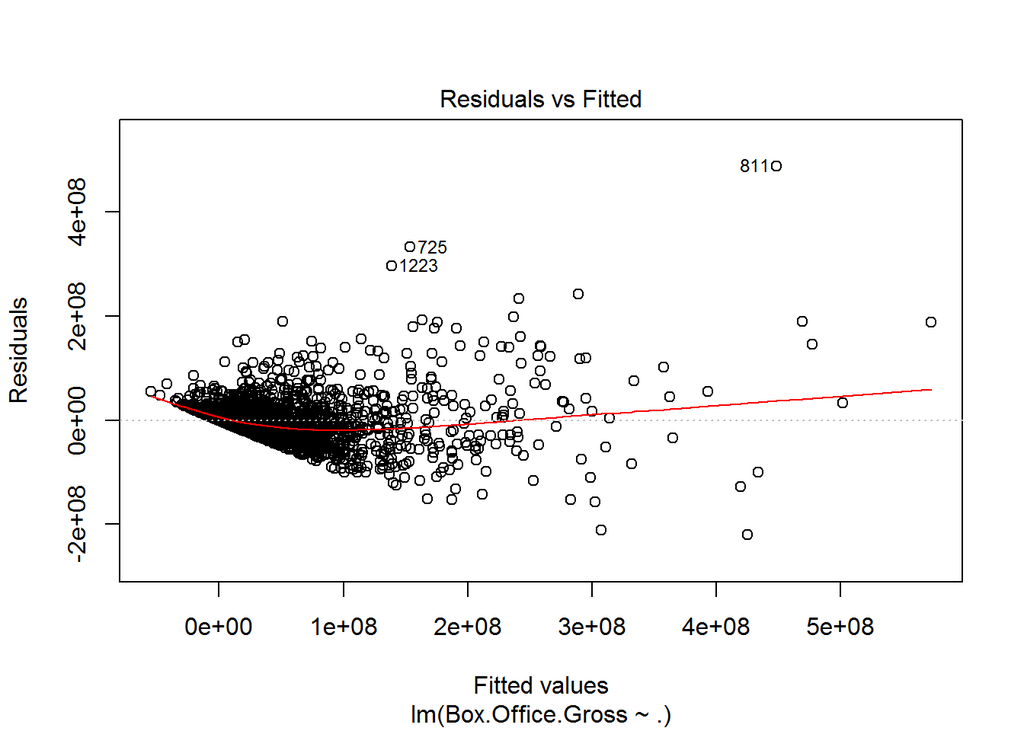

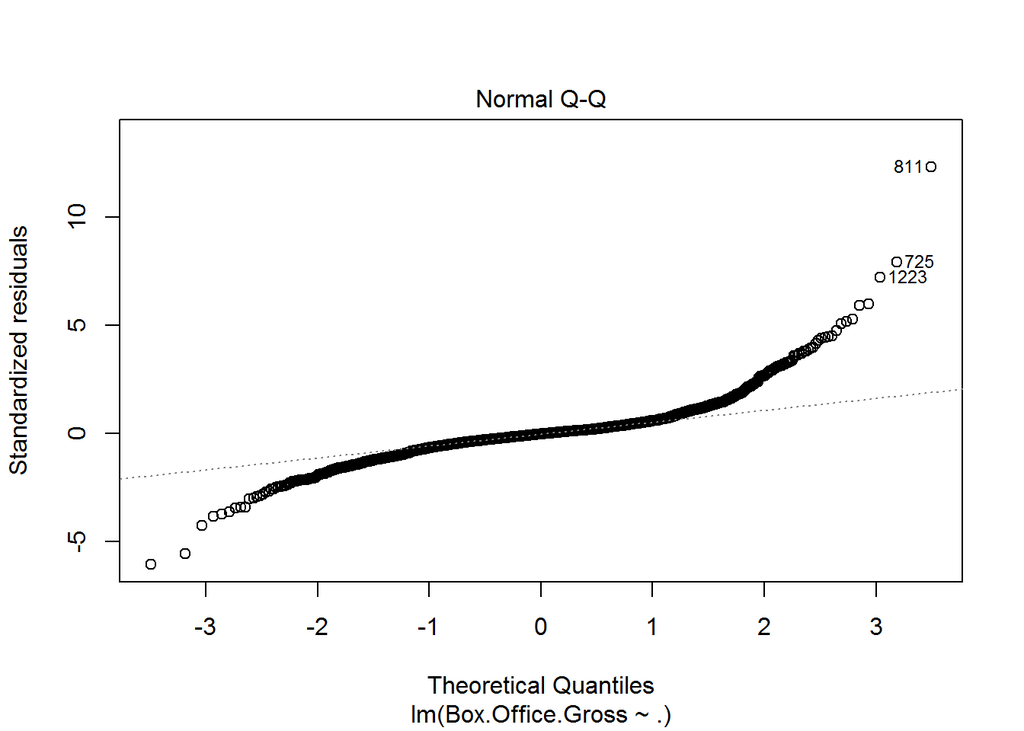

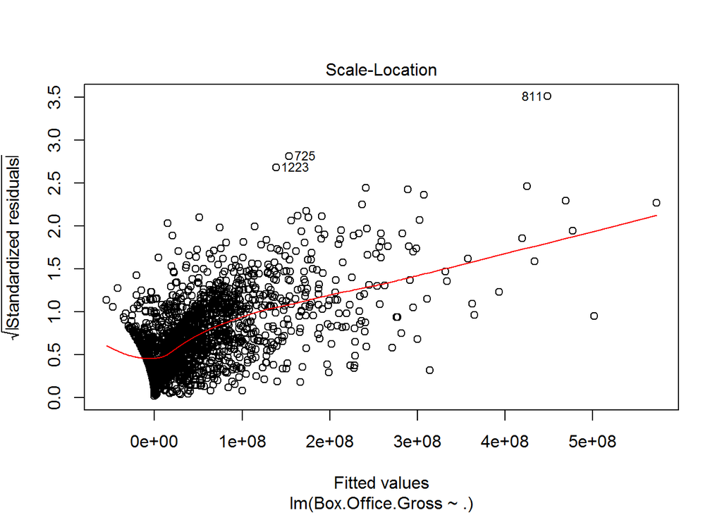

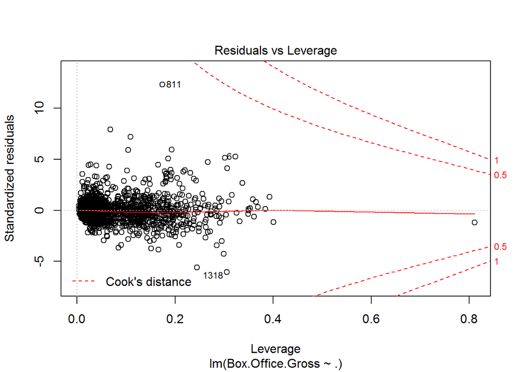

```r
plot(train.fit)
```

Predict using test set and calculate rmse.

```r
pred <- predict(train.fit,test)
test$pred.lm <- pred
```

There’re negative predicted value here, which means our model is not performing very well.

```r
pred.result <- test %>%
  select(Box.Office.Gross,pred.lm)
pred.result$ratio.lm <- round(pred.result$pred.lm/pred.result$Box.Office.Gross,2)
head(pred.result)
```

```
##    Box.Office.Gross   pred.lm ratio.lm
## 2         238632124 145721926     0.61
## 11        652270625 144824639     0.22
## 12         13100042  17054195     1.30
## 13         99967670  38934259     0.39
## 14         43818839 117959989     2.69
## 19         77222099 151059693     1.96
```

```r
RMSE.lm <- sqrt(mean((test$pred.lm-test$Box.Office.Gross)^2))
RMSE.lm
```

```
## [1] 51503153
```

8. Fit regression tree model

```r
library(rpart)
library(rpart.plot)
```

```r
tree.fit <- rpart(formula=Box.Office.Gross~.,data=train,method="anova")
print(tree.fit)
```

```
## n= 2091
##
## node), split, n, deviance, yval
##       * denotes terminal node
##
##  1) root 2091 1.254480e+19  47114260
##    2) imdb_votes< 300139 1936 4.614925e+18  34045430
##      4) imdb_votes< 99345.5 1537 1.442874e+18  20757900
##        8) Budget< 1.875e+07 877 2.536709e+17   9518408 *
##        9) Budget>=1.875e+07 660 9.312013e+17  35692810 *
##      5) imdb_votes>=99345.5 399 1.855327e+18  85230730
##       10) Budget< 7.35e+07 273 6.453383e+17  64527910 *
##       11) Budget>=7.35e+07 126 8.394580e+17 130086800 *
##    3) imdb_votes>=300139 155 3.469194e+18 210348200
##      6) Budget< 1.675e+08 115 1.268800e+18 161453700
##       12) Budget< 4.45e+07 50 2.963738e+17  99531830 *
##       13) Budget>=4.45e+07 65 6.332364e+17 209086000 *
##      7) Budget>=1.675e+08 40 1.135055e+18 350919600
##       14) imdb_votes< 629872.5 32 3.091251e+17 294950200 *
##       15) imdb_votes>=629872.5 8 3.247175e+17 574797200 *
```

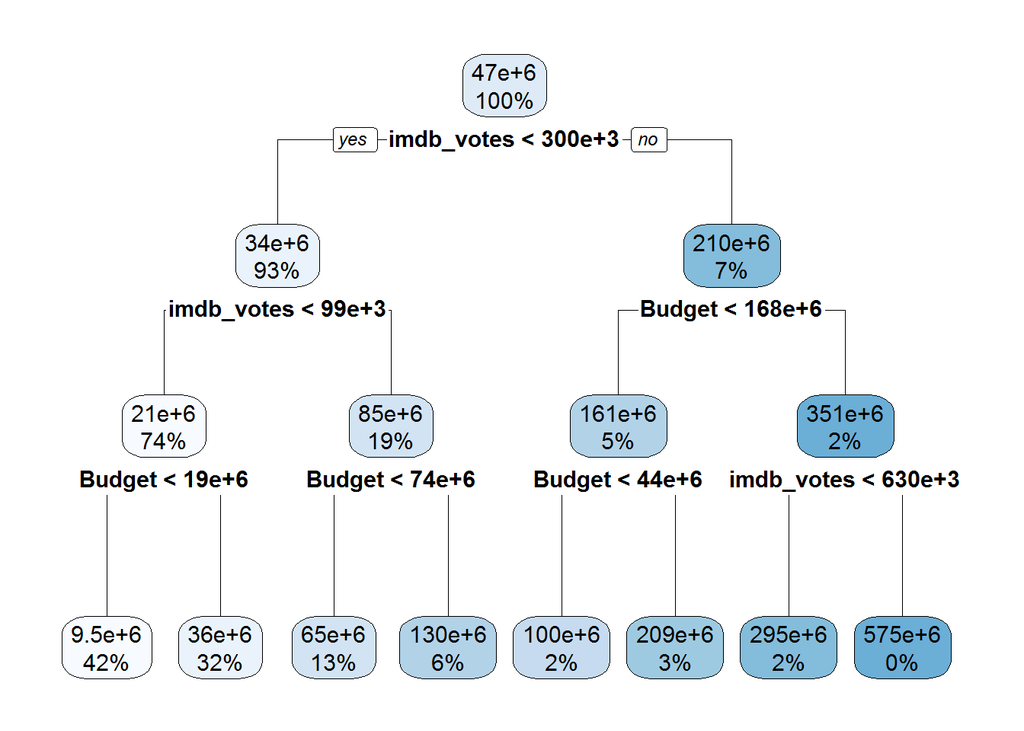

```r
rpart.plot(tree.fit)
```

```r
pred.tree <- predict(tree.fit,test)

pred.result$pred.tree <- pred.tree
pred.result$ratio.tree <- round(pred.result$pred.tree/pred.result$Box.Office.Gross,2)
head(pred.result)
```

```
##    Box.Office.Gross   pred.lm ratio.lm pred.tree ratio.tree
## 2         238632124 145721926     0.61  64527909       0.27
## 11        652270625 144824639     0.22 209085978       0.32
## 12         13100042  17054195     1.30  35692810       2.72
## 13         99967670  38934259     0.39  35692810       0.36
## 14         43818839 117959989     2.69  64527909       1.47
## 19         77222099 151059693     1.96 130086829       1.68
```

```r
RMSE.tree <- sqrt(mean((pred.tree-test$Box.Office.Gross)^2))
RMSE.tree
```

```
## [1] 51786372
```

9. Fit random forest model

```r
library(randomForest)
```

```r
names(train) <- make.names(names(train))
rf.fit <- randomForest(formula=Box.Office.Gross~.,data=train,importance=TRUE)
rf.fit
```

```
##
## Call:
##  randomForest(formula = Box.Office.Gross ~ ., data = train, importance = TRUE)
##                Type of random forest: regression
##                      Number of trees: 500
## No. of variables tried at each split: 43
##
##           Mean of squared residuals: 1.772134e+15
##                     % Var explained: 70.46
```

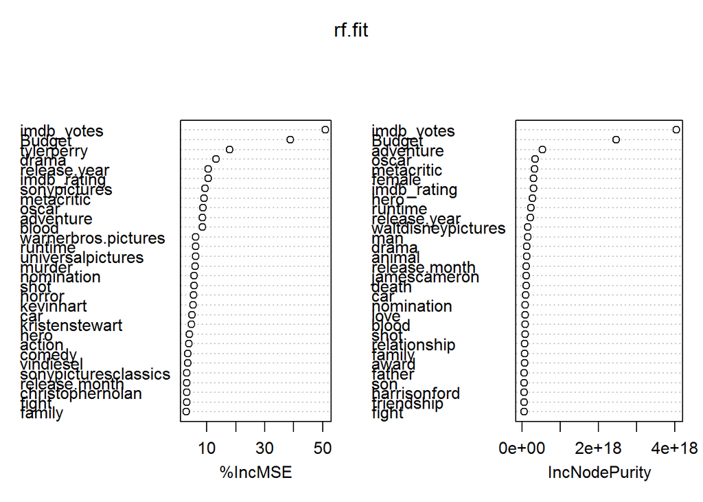

```r
varImpPlot(rf.fit)
```

70.47% of variance explained, better than linear regression with lower rmse.

```r
names(test) <- make.names(names(test))
pred.rf <- predict(rf.fit,test)

pred.result$pred.rf <- pred.rf
pred.result$ratio.rf <- round(pred.rf/pred.result$Box.Office.Gross,2)
head(pred.result)
```

```
##    Box.Office.Gross   pred.lm ratio.lm pred.tree ratio.tree   pred.rf
## 2         238632124 145721926     0.61  64527909       0.27 109346248
## 11        652270625 144824639     0.22 209085978       0.32 198392702
## 12         13100042  17054195     1.30  35692810       2.72  50842791
## 13         99967670  38934259     0.39  35692810       0.36  38998038
## 14         43818839 117959989     2.69  64527909       1.47  72896294
## 19         77222099 151059693     1.96 130086829       1.68 103265281
##    ratio.rf
## 2      0.46
## 11     0.30
## 12     3.88
## 13     0.39
## 14     1.66
## 19     1.34
```

```r
RMSE.rf <- sqrt(mean((pred.rf-test$Box.Office.Gross)^2))
RMSE.rf
```

```
## [1] 43049543
```

10. Fit xgboost

```r
library(xgboost)
```

```r
xgb.fit <- xgboost(data=as.matrix(train[,-5]),
                   nfold=5,
                   label=as.matrix(train$Box.Office.Gross),
                   nrounds=2200,
                   verbose=FALSE,
                   objective="reg:linear",
                   eval_metric="rmse",
                   nthread=8,
                   eta=0.01,
                   gamma=0.0468,
                   max_depth=15,
                   min_child_weight=1.7817,
                   subsample=0.5213,
                   colsample_bytree=0.4603)
```

```r
xgb.fit
```

```
## ##### xgb.Booster
## raw: 25.3 Mb
## call:
##   xgb.train(params = params, data = dtrain, nrounds = nrounds,
##     watchlist = watchlist, verbose = verbose, print_every_n = print_every_n,
##     early_stopping_rounds = early_stopping_rounds, maximize = maximize,
##     save_period = save_period, save_name = save_name, xgb_model = xgb_model,
##     callbacks = callbacks, nfold = 5, objective = "reg:linear",
##     eval_metric = "rmse", nthread = 8, eta = 0.01, gamma = 0.0468,
##     max_depth = 15, min_child_weight = 1.7817, subsample = 0.5213,
##     colsample_bytree = 0.4603)
## params (as set within xgb.train):
##   nfold = "5", objective = "reg:linear", eval_metric = "rmse", nthread = "8", eta = "0.01", gamma = "0.0468", max_depth = "15", min_child_weight = "1.7817", subsample = "0.5213", colsample_bytree = "0.4603", silent = "1"
## xgb.attributes:
##   niter
## callbacks:
##   cb.save.model(save_period = save_period, save_name = save_name)
## niter: 2200
```

```r
library(Metrics)
```

```r
pred.xgb <- predict(xgb.fit,newdata=as.matrix(test[,-5]))

pred.result$pred.xgb <- pred.xgb
pred.result$ratio.xgb <- round(pred.xgb/pred.result$Box.Office.Gross,2)
head(pred.result)
```

```
##    Box.Office.Gross   pred.lm ratio.lm pred.tree ratio.tree   pred.rf
## 2         238632124 145721926     0.61  64527909       0.27 109346248
## 11        652270625 144824639     0.22 209085978       0.32 198392702
## 12         13100042  17054195     1.30  35692810       2.72  50842791
## 13         99967670  38934259     0.39  35692810       0.36  38998038
## 14         43818839 117959989     2.69  64527909       1.47  72896294
## 19         77222099 151059693     1.96 130086829       1.68 103265281
##    ratio.rf  pred.xgb ratio.xgb
## 2      0.46 105359560      0.44
## 11     0.30 177018816      0.27
## 12     3.88  38901036      2.97
## 13     0.39  32179930      0.32
## 14     1.66  60834128      1.39
## 19     1.34 130545744      1.69
```

```r
RMSE.xgb <- rmse(test$Box.Office.Gross,pred.xgb)
RMSE.xgb
```

```
## [1] 41942594
```

xgb has the lowest rmse among the 4 models.